# 06_Analyses_on_Hospital_Discharge

Arthur M. Albuquerque

May 24, 2021

```r
# Load packages

# Ensures the package "pacman" is installed
if (!require("pacman")) install.packages("pacman")

# p_load() installs (if necessary) and loads the following packages

pacman::p_load(plyr, # for the Varying baseline risk calculations
               magrittr, # same as above
               rio, # to import/export files
               tidyverse, # Data wrangling and plotting
               kableExtra, # To create tables
               flextable, # To create tables
               here, # To find file paths within R project
               metafor, # To create priors from meta-analysis
               janitor, # To change column names
               ggdist, # To plot distributions
               patchwork, # To arrange plots
               rcartocolor, # Color palettes
               Cairo # To export PDF files
               )

# Load data on respiratory support subgroups

d1 = import((here("final_analyses", "output", "data", # file path
                   "respiratory-data.csv")),           # file name
             header = T)

# Load data on corticosteroids subgroups

d2 = import(here("final_analyses", "data", # file path
                            "corticosteroids_subgroup_extracted-data.xlsx"))

d2 = clean_names(d2)
```

In this document, we will compile most of the analyses regarding hospital discharge. First, we will derive the risk difference from odds ratio. Next, we will perform the main analyses and sensitivity analyses. We will be brief, so for complete explanation on the rationale of the analyses, please check the files on the mortality outcome.

In summary, this document shows what all other documents has shown, but now the spotlight is on the hospital discharge outcome.

**Of note, for this outcome, positive log-odds ratio, odds ratio greater than 1, and negative risk differences mean benefit.**

# Calculating posterior distributions

## Priors and RECOVERY

### Use of corticosteroids

#### Not using

First, let’s calculate and visualize the **log-odds ratio** from the RECOVERY trial.

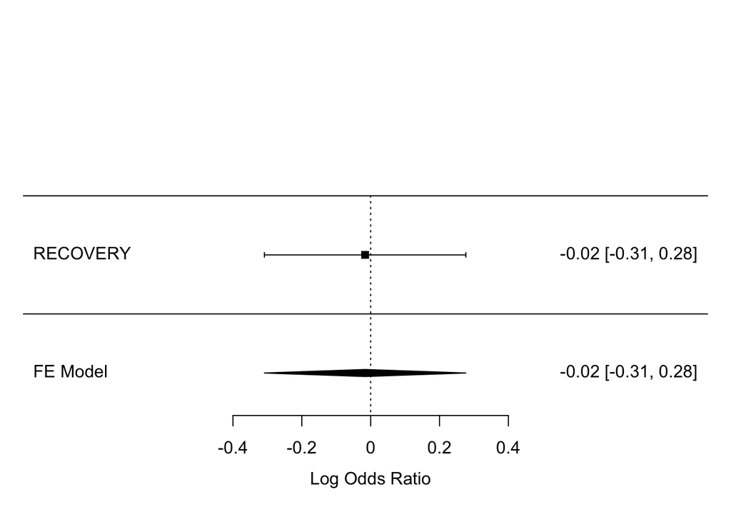

```r
logOR_recovery_not_using =
  rma(
    # Outcome
    measure = "OR", # Log-odds ratio

    # Tocilizumab group
    ai = events_toci,
    n1i = total_toci,

    # Control group
    ci = events_control,
    n2i = total_control,

    data = d2 %>% filter(outcome == "discharge",
                         corticosteroids == 0,
                         trial == "RECOVERY"),

     method = "REML",

    slab = paste(trial)
  )

forest(logOR_recovery_not_using)
```

Now, let’s calculate and visualize the **log-odds ratio** from the other trials. The pooled result from this random-effect meta-analysis will be used as the estimate for the distribution of prior regarding this subgroup.

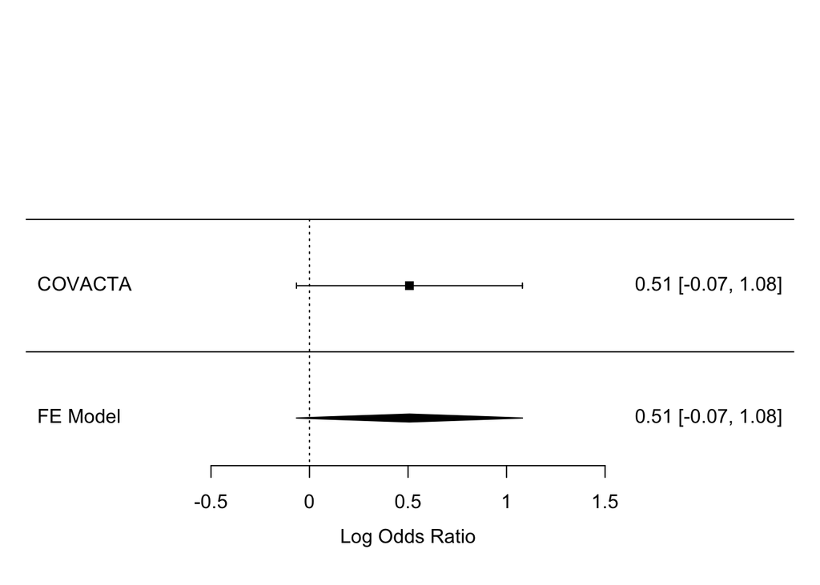

```r
# Simple oxygen

logOR_prior_not_using =
  rma(
    # Outcome
    measure = "OR", # Log-odds ratio

    # Tocilizumab group
    ai = events_toci,
    n1i = total_toci,

    # Control group
    ci = events_control,
    n2i = total_control,

    data = d2 %>% filter(outcome == "discharge",
                         corticosteroids == 0,
                         trial != "RECOVERY"),

     method = "REML",

    slab = paste(trial)
  )

forest(logOR_prior_not_using)
```

#### Using

Let’s calculate and visualize the **log-odds ratio** from the RECOVERY trial.

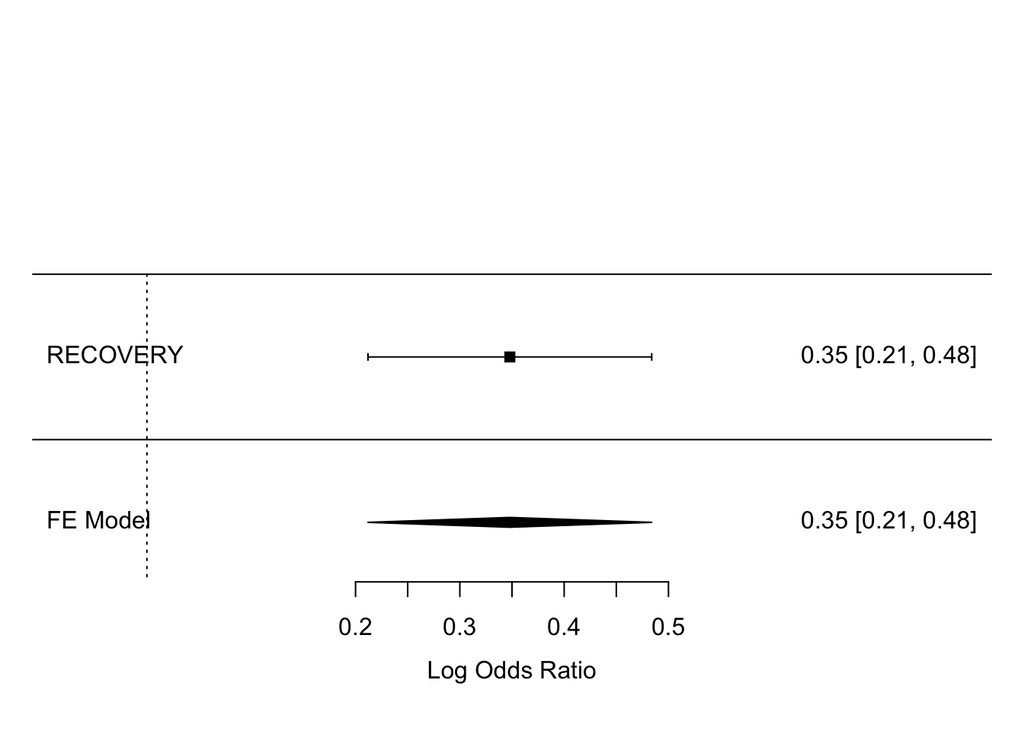

```r
logOR_recovery_using =
  rma(
    # Outcome
    measure = "OR", # Log-odds ratio

    # Tocilizumab group
    ai = events_toci,
    n1i = total_toci,

    # Control group
    ci = events_control,
    n2i = total_control,

    data = d2 %>% filter(outcome == "discharge",
                         corticosteroids == 1,
                         trial == "RECOVERY"),

     method = "REML",

    slab = paste(trial)
  )

forest(logOR_recovery_using)
```

Now, let’s calculate and visualize the **log-odds ratio** from the other trials. The pooled result from this random-effect meta-analysis will be used as the estimate for the distribution of prior regarding this subgroup.

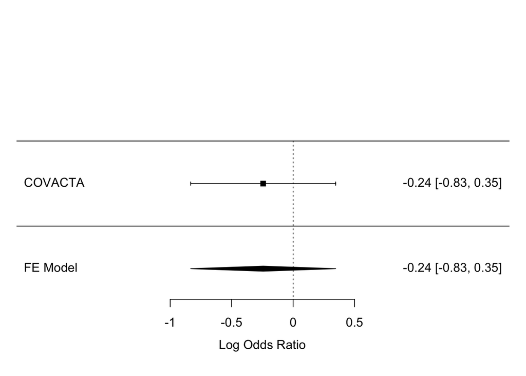

```r
# Simple oxygen

logOR_prior_using =
  rma(
    # Outcome
    measure = "OR", # Log-odds ratio

    # Tocilizumab group
    ai = events_toci,
    n1i = total_toci,

    # Control group
    ci = events_control,
    n2i = total_control,

    data = d2 %>% filter(outcome == "discharge",
                         corticosteroids == 1,
                         trial != "RECOVERY"),

     method = "REML",

    slab = paste(trial)
  )

forest(logOR_prior_using)
```

### Respiratory support subgroups

#### Simple oxygen only

Let’s calculate and visualize the **log-odds ratio** from the RECOVERY trial.

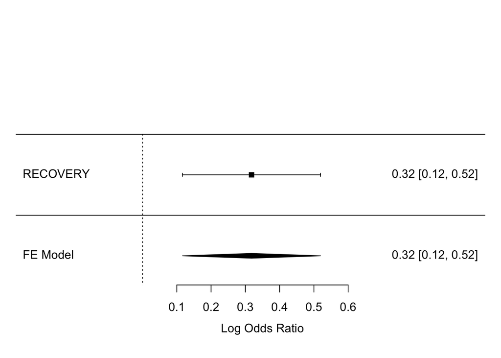

```r
logOR_recovery_simple =
  rma(
    # Outcome
    measure = "OR", # Log-odds ratio

    # Tocilizumab group
    ai = events_toci,
    n1i = total_toci,

    # Control group
    ci = events_control,
    n2i = total_control,

    data = d1 %>% filter(outcome == "discharge",
                         oxygen == "simple oxygen",
                         trial == "RECOVERY"),

     method = "REML",

    slab = paste(trial)
  )

forest(logOR_recovery_simple)
```

Now, let’s calculate and visualize the **log-odds ratio** from the other trials. The pooled result from this random-effect meta-analysis will be used as the estimate for the distribution of prior regarding this subgroup.

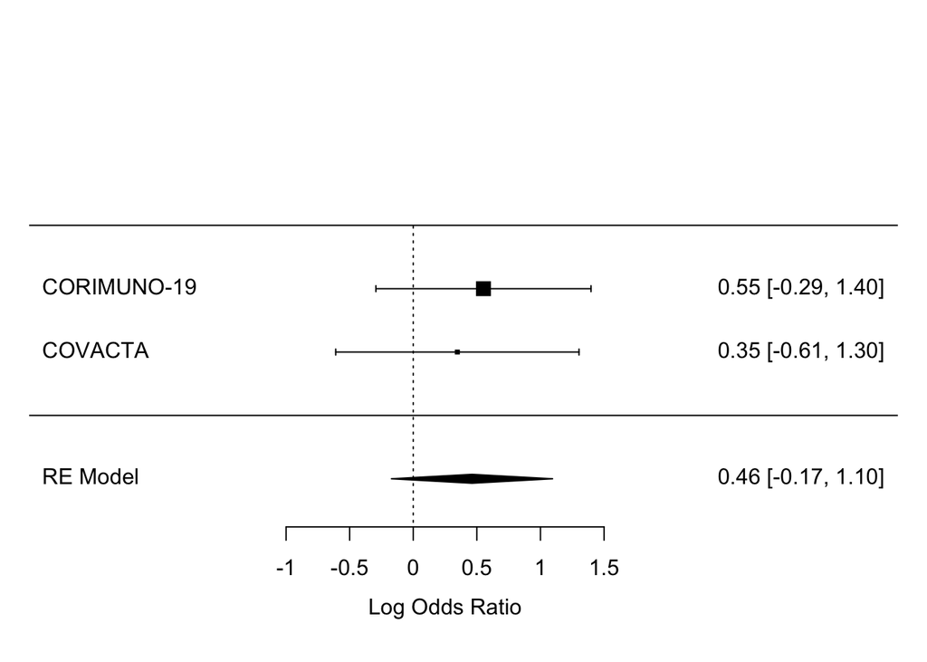

```r
logOR_prior_simple =
  rma(
    # Outcome
    measure = "OR", # Log-odds ratio

    # Tocilizumab group
    ai = events_toci,
    n1i = total_toci,

    # Control group
    ci = events_control,
    n2i = total_control,

    data = d1 %>% filter(outcome == "discharge",
                         oxygen == "simple oxygen",
                         trial != "RECOVERY"),

     method = "REML",

    slab = paste(trial)
  )

forest(logOR_prior_simple)
```

#### Non-invasive ventilation

Let’s calculate and visualize the **log-odds ratio** from the RECOVERY trial.

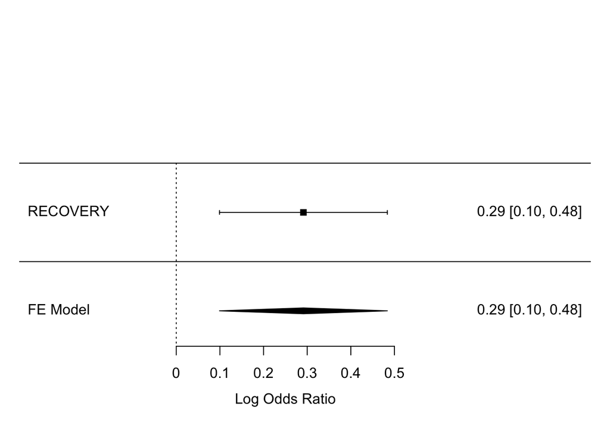

```r
logOR_recovery_noninvasive =
  rma(
    # Outcome
    measure = "OR", # Log-odds ratio

    # Tocilizumab group
    ai = events_toci,
    n1i = total_toci,

    # Control group
    ci = events_control,
    n2i = total_control,

    data = d1 %>% filter(outcome == "discharge",
                         oxygen == "non-invasive ventilation",
                         trial == "RECOVERY"),

     method = "REML",

    slab = paste(trial)
  )

forest(logOR_recovery_noninvasive)
```

Now, let’s calculate and visualize the **log-odds ratio** from the other trials. The pooled result from this random-effect meta-analysis will be used as the estimate for the distribution of prior regarding this subgroup.

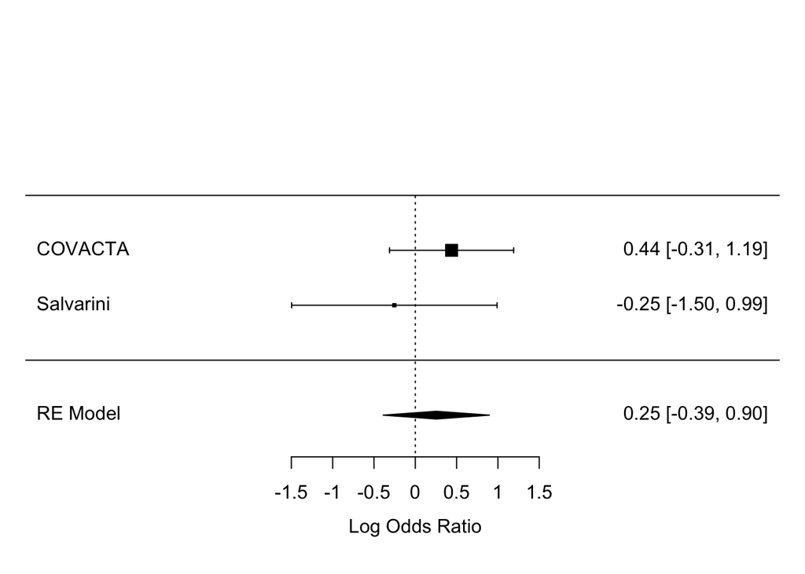

```r
logOR_prior_noninvasive =
  rma(
    # Outcome
    measure = "OR", # Log-odds ratio

    # Tocilizumab group
    ai = events_toci,
    n1i = total_toci,

    # Control group
    ci = events_control,
    n2i = total_control,

    data = d1 %>% filter(outcome == "discharge",
                         oxygen == "non-invasive ventilation",
                         trial != "RECOVERY"),

     method = "REML",

    slab = paste(trial)
  )

forest(logOR_prior_noninvasive)
```

#### Invasive mechanical ventilation

Let’s calculate and visualize the **log-odds ratio** from the RECOVERY trial.

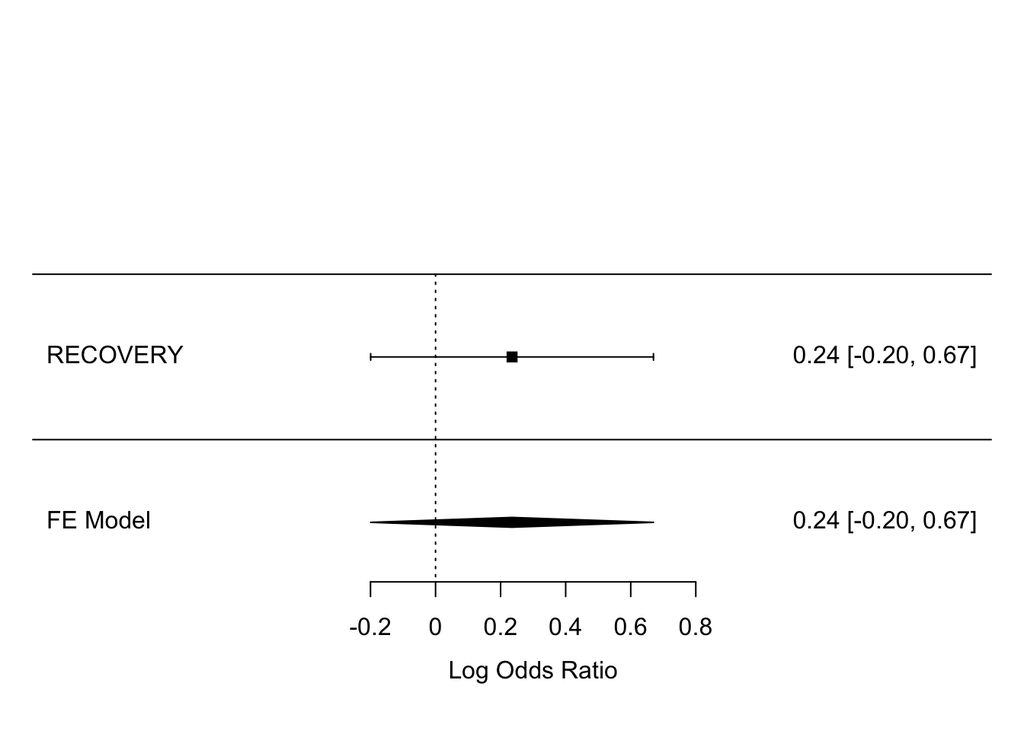

```r
logOR_recovery_invasive =
  rma(
    # Outcome
    measure = "OR", # Log-odds ratio

    # Tocilizumab group
    ai = events_toci,
    n1i = total_toci,

    # Control group
    ci = events_control,
    n2i = total_control,

    data = d1 %>% filter(outcome == "discharge",
                         oxygen == "invasive ventilation",
                         trial == "RECOVERY"),

     method = "REML",

    slab = paste(trial)
  )

forest(logOR_recovery_invasive)
```

Now, let’s calculate and visualize the **log-odds ratio** from the other trials. The pooled result from this random-effect meta-analysis will be used as the estimate for the distribution of prior regarding this subgroup.

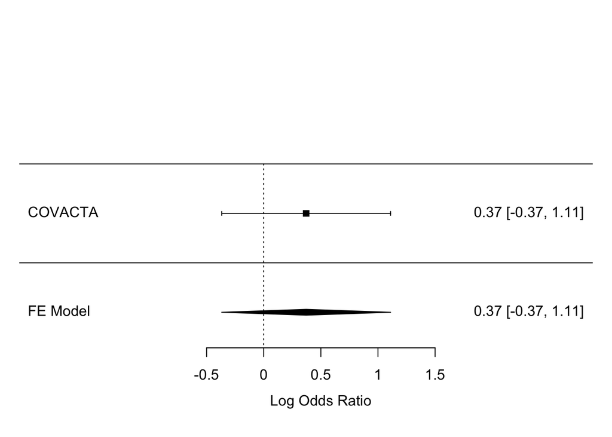

```r
logOR_prior_invasive =
  rma(
    # Outcome
    measure = "OR", # Log-odds ratio

    # Tocilizumab group
    ai = events_toci,
    n1i = total_toci,

    # Control group
    ci = events_control,
    n2i = total_control,

    data = d1 %>% filter(outcome == "discharge",
                         oxygen == "invasive ventilation",
                         trial != "RECOVERY"),

     method = "REML",

    slab = paste(trial)
  )

forest(logOR_prior_invasive)
```

## Posterior Distribution

```r
## Load custom functions

# To generate normal conjugate posterior probabilities

source(here("final_analyses", "script", "functions", "analyses", # file path
            "conjugate_normal_posterior.R"))                     # file name

# To generate posterior probabilities with an evidence-based prior
# (it requires "conjugate_normal_posterior.R" )

source(here("final_analyses", "script", "functions", "analyses", # file path
            "normal_approximation_logOR.R"))                     # file name

# To generate posterior probabilities with multiple priors
# (it requires "conjugate_normal_posterior.R" )

source(here("final_analyses", "script", "functions", "analyses", # file path
            "logOR_normal_approximation_multiple_priors.R"))     # file name

# To compile all posteriors into a tibble

source(here("final_analyses", "script", "functions", "analyses", # file path
            "tibble_all_posteriors_logOR.R"))                      # file name
```

Note that positive log(OR) means benefit for the hospital discharge outcome. Thus, in this document, the optimistic prior has a positive mean and the pessimistic the opposite.

```r
## Use of corticosteroids

# Not using
posteriors_not_using_discharge =
  logOR_normal_approximation_multiple_priors(
  # Data object with evidence-based posterior from normal_approximation()
  posterior_not_using_discharge,
  "discharge", # Outcome (within quotes)
  posteriors_not_using_discharge # Name for the final output with data+prior+posterior
  )
```

```
## Post mean =  -0.01606234 , Post Var =  0.0222785 , Post SD =  0.1492598
## Post mean =  0.09201482 , Post Var =  0.01767745 , Post SD =  0.1329566
## Post mean =  -0.01274508 , Post Var =  0.01767745 , Post SD =  0.1329566
## Post mean =  0.03333988 , Post Var =  0.01767745 , Post SD =  0.1329566
## Post mean =  -0.05883004 , Post Var =  0.01767745 , Post SD =  0.1329566
```

```r
# Using
posteriors_using_discharge =
  logOR_normal_approximation_multiple_priors(
  # Data object with evidence-based posterior from normal_approximation()
  posterior_using_discharge,
  "discharge", # Outcome (within quotes)
  posteriors_using_discharge # Name for the final output with data+prior+posterior
  )
```

```
## Post mean =  0.3479437 , Post Var =  0.004814994 , Post SD =  0.06939016
## Post mean =  0.3180544 , Post Var =  0.004571678 , Post SD =  0.06761418
## Post mean =  0.330361 , Post Var =  0.004571678 , Post SD =  0.06761418
## Post mean =  0.3416372 , Post Var =  0.004571678 , Post SD =  0.06761418
## Post mean =  0.3190848 , Post Var =  0.004571678 , Post SD =  0.06761418
```

```r
## Respiratory support

# Simple oxygen only
posteriors_simple_discharge =
  logOR_normal_approximation_multiple_priors(
  # Data object with evidence-based posterior from normal_approximation()
  posterior_simple_discharge,
  "discharge", # Outcome (within quotes)
  posteriors_simple_discharge # Name for the final output with data+prior+posterior
  )
```

```
## Post mean =  0.3179829 , Post Var =  0.0105669 , Post SD =  0.1027954
## Post mean =  0.331199 , Post Var =  0.009596272 , Post SD =  0.09796056
## Post mean =  0.2887745 , Post Var =  0.009596272 , Post SD =  0.09796056
## Post mean =  0.3092716 , Post Var =  0.009596272 , Post SD =  0.09796056
## Post mean =  0.2682773 , Post Var =  0.009596272 , Post SD =  0.09796056
```

```r
# Non-invasive ventilation
posteriors_noninvasive_discharge =
  logOR_normal_approximation_multiple_priors(
  # Data object with evidence-based posterior from normal_approximation()
  posterior_noninvasive_discharge,
  "discharge", # Outcome (within quotes)
  posteriors_noninvasive_discharge # Name for the final output with data+prior+posterior
  )
```

```
## Post mean =  0.2913939 , Post Var =  0.00962873 , Post SD =  0.09812609
## Post mean =  0.2883111 , Post Var =  0.008837633 , Post SD =  0.09400869
## Post mean =  0.267453 , Post Var =  0.008837633 , Post SD =  0.09400869
## Post mean =  0.2857867 , Post Var =  0.008837633 , Post SD =  0.09400869
## Post mean =  0.2491193 , Post Var =  0.008837633 , Post SD =  0.09400869
```

```r
# Invasive mechanical ventilation
posteriors_invasive_discharge =
  logOR_normal_approximation_multiple_priors(
  # Data object with evidence-based posterior from normal_approximation()
  posterior_invasive_discharge,
  "discharge", # Outcome (within quotes)
  posteriors_invasive_discharge # Name for the final output with data+prior+posterior
  )
```

```
## Post mean =  0.2352049 , Post Var =  0.04918534 , Post SD =  0.2217777
## Post mean =  0.2702109 , Post Var =  0.03654003 , Post SD =  0.1911545
## Post mean =  0.1747349 , Post Var =  0.03654003 , Post SD =  0.1911545
## Post mean =  0.2321048 , Post Var =  0.03654003 , Post SD =  0.1911545
## Post mean =  0.117365 , Post Var =  0.03654003 , Post SD =  0.1911545
```

```r
## Use of corticosteroids

# Not using
samples_logOR_posteriors_not_using_discharge =
  tibble_all_posteriors_logOR(posteriors_not_using_discharge)

# Using
samples_logOR_posteriors_using_discharge =
  tibble_all_posteriors_logOR(posteriors_using_discharge)

## Respiratory support

# Simple oxygen only
samples_logOR_posteriors_simple_discharge =
  tibble_all_posteriors_logOR(posteriors_simple_discharge)

# Non-invasive ventilation
samples_logOR_posteriors_noninvasive_discharge =
  tibble_all_posteriors_logOR(posteriors_noninvasive_discharge)

# Invasive mechanical ventilation
samples_logOR_posteriors_invasive_discharge =
  tibble_all_posteriors_logOR(posteriors_invasive_discharge)
```

```r
## Use of corticosteroids

# Not using
samples_posteriors_not_using_discharge =
  samples_logOR_posteriors_not_using_discharge %>%
  pivot_longer(
    cols = c('Non-informative':'Pessimistic'),
    names_to = "Underlying_Prior", values_to = "log(OR)"
  )

# Using
samples_posteriors_using_discharge =
  samples_logOR_posteriors_using_discharge %>%
  pivot_longer(
    cols = c('Non-informative':'Pessimistic'),
    names_to = "Underlying_Prior", values_to = "log(OR)"
  )

## Respiratory support

# Simple oxygen only
samples_posteriors_simple_discharge =
  samples_logOR_posteriors_simple_discharge %>%
  pivot_longer(
    cols = c('Non-informative':'Pessimistic'),
    names_to = "Underlying_Prior", values_to = "log(OR)"
  )

# Non-invasive ventilation
samples_posteriors_noninvasive_discharge =
  samples_logOR_posteriors_noninvasive_discharge %>%
  pivot_longer(
    cols = c('Non-informative':'Pessimistic'),
    names_to = "Underlying_Prior", values_to = "log(OR)"
  )

# Invasive mechanical ventilation
samples_posteriors_invasive_discharge =
  samples_logOR_posteriors_invasive_discharge %>%
  pivot_longer(
    cols = c('Non-informative':'Pessimistic'),
    names_to = "Underlying_Prior", values_to = "log(OR)"
  )
```

```r
## Use of corticosteroids

# Not using
samples_posteriors_not_using_discharge =
  samples_posteriors_not_using_discharge %>%
  mutate(OR = exp(`log(OR)`))

# Using
samples_posteriors_using_discharge =
  samples_posteriors_using_discharge %>%
  mutate(OR = exp(`log(OR)`))

## Respiratory support

# Simple oxygen only
samples_posteriors_simple_discharge =
  samples_posteriors_simple_discharge %>%
  mutate(OR = exp(`log(OR)`))

# Non-invasive ventilation
samples_posteriors_noninvasive_discharge =
  samples_posteriors_noninvasive_discharge %>%
  mutate(OR = exp(`log(OR)`))

# Invasive mechanical ventilation
samples_posteriors_invasive_discharge =
  samples_posteriors_invasive_discharge %>%
  mutate(OR = exp(`log(OR)`))
```

#### Baseline risks in RECOVERY

Remember that higher risks of hospital discharge is a benefitial outcome.

| Subgroup | Baseline Risk in Control Group (%) |
| --- | --- |
| **Use of corticosteroids** |  |
| Not using | 45.8 |
| Using | 50.7 |
| **Respiratory support** |  |
| Simple oxygen only | 68.1 |
| Non-invasive ventilation | 41.8 |
| Invasive mechanical | 16.0 |

```r
# BR = Baseline Risk
# OR = Odds Ratio

RD_fun = function(BR,OR)
  {
( BR*(BR-1)*(OR-1) ) / ( BR*OR - BR+1)
}
```

```r
# Calculating the risk differences

### Use of corticosteroids

## Not using

# Define baseline risk
BR_not_using = d2 %>%
    filter(trial == "RECOVERY",
           corticosteroids == 0, # Not using
           outcome == "discharge") %>%
      summarise(n = events_control/total_control) %>%
      pull()

samples_posteriors_not_using_discharge =
  samples_posteriors_not_using_discharge %>%
  # Apply formula from Doi et al., 2020
  mutate(RD = RD_fun(BR_not_using,
                     OR))

## Using

# Define baseline risk
BR_using = d2 %>%
    filter(trial == "RECOVERY",
           corticosteroids == 1, # Using
           outcome == "discharge") %>%
      summarise(n = events_control/total_control) %>%
      pull()

samples_posteriors_using_discharge =
  samples_posteriors_using_discharge %>%
  # Apply formula from Doi et al., 2020
  mutate(RD = RD_fun(BR_using,
                     OR))

### Respiratory support

## Simple oxygen

# Define baseline risk
BR_simple = d1 %>%
    filter(trial == "RECOVERY",
           oxygen == "simple oxygen",
           outcome == "discharge") %>%
      summarise(n = events_control/total_control) %>%
      pull()

samples_posteriors_simple_discharge =
  samples_posteriors_simple_discharge %>%
  # Apply formula from Doi et al., 2020
  mutate(RD = RD_fun(BR_simple,
                     OR))

## Non-invasive

# Define baseline risk
BR_noninvasive = d1 %>%
    filter(trial == "RECOVERY",
           oxygen == "non-invasive ventilation",
           outcome == "discharge") %>%
      summarise(n = events_control/total_control) %>%
      pull()

samples_posteriors_noninvasive_discharge =
  samples_posteriors_noninvasive_discharge %>%
  # Apply formula from Doi et al., 2020
  mutate(RD = RD_fun(BR_noninvasive,
                     OR))

## Invasive mechanical ventilation

# Define baseline risk
BR_invasive = d1 %>%
    filter(trial == "RECOVERY",
           oxygen == "invasive ventilation",
           outcome == "discharge") %>%
      summarise(n = events_control/total_control) %>%
      pull()

samples_posteriors_invasive_discharge =
  samples_posteriors_invasive_discharge %>%
  # Apply formula from Doi et al., 2020
  mutate(RD = RD_fun(BR_invasive,
                     OR))
```

#### Summary

To display some of our calculations, we will now plot the posterior distributions for log-odds ratio, odds ratio and risk difference for a single subgroup (not using corticosteroids).

We note that **log-odds ratios** *greater* than $0$, **odds-ratios** *greater* than $1$ and **risk differences** *lower* than $0$ mean benefit for the hospital discharge outcome.

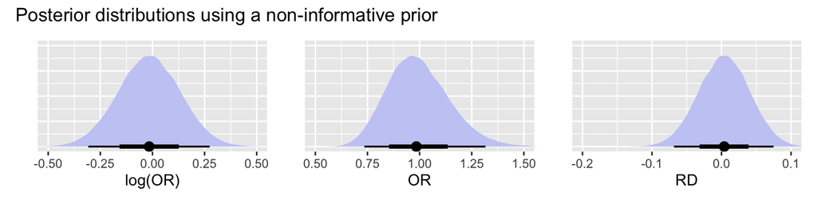

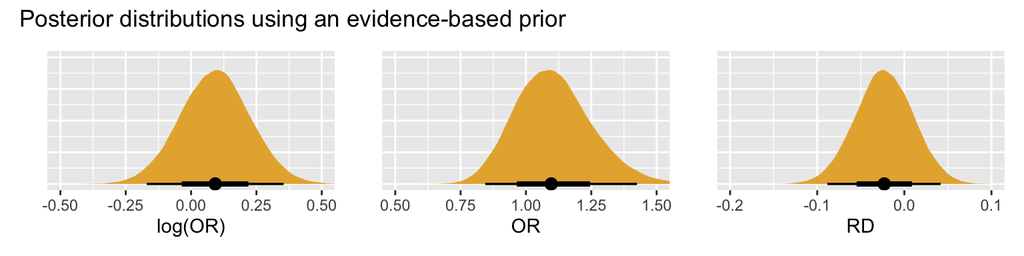

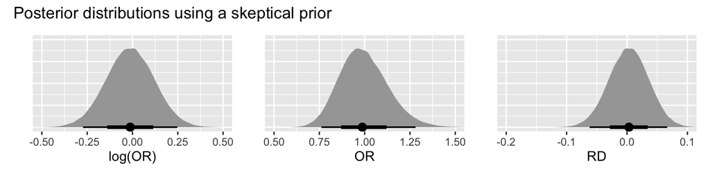

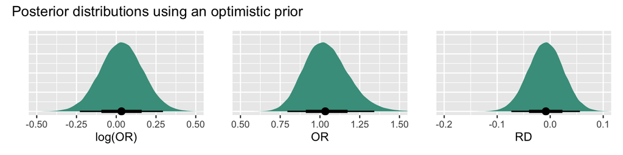

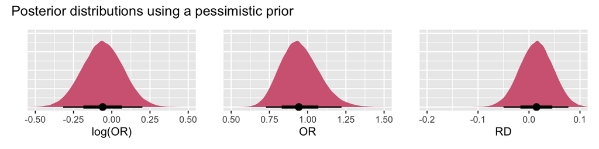

# Analyses

We are going to replicate the same analyses done regarding the mortality outcome. Of course, now with the hospital discharge data.

One could load all data objects generated above without the need of running all code chunks again. THe purpose of the following code chunk is to facilitate to this end, by loading the data objects stored elsewhere.

```r
## Load objects with mean + SD of multiple priors along with
## RECOVERY data and posterior distributions

#load(file = here("final_analyses", "output", "data", "analyses", # file path
#                 "data_prior_posteriors_mean_sd_discharge.RData"))   # file name

## Load posterior distributions' samples with logOR, OR and RD

# I uploaded these data objects to OSF since the .RData file is 56MB.
# Here I load all data files directly from OSF without having to download it
# to my/your PC

#samples = url("https://osf.io/7t32f/download?version=1")
#load(gzcon(samples))
```

## Main figures and tables

```r
# Load original data extraction table

d = import((here("final_analyses", "output", "data", # file path
                   "respiratory-data.csv")),           # file name
             header = T)
d = d %>%
  as_tibble() %>%
  select(!starts_with("X"))

# Create different variables per subgroup

priors_simple_oxygen_raw =
  d %>%
  filter(
    trial != "RECOVERY",
    oxygen == "simple oxygen",
    outcome == "discharge"
  )

priors_noninvasive_raw =
  d %>%
  filter(
    trial != "RECOVERY",
    oxygen == "non-invasive ventilation",
    outcome == "discharge"
  )

priors_invasive_raw =
  d %>%
  filter(
    trial != "RECOVERY",
    oxygen == "invasive ventilation",
    outcome == "discharge"
  )

recovery_simple_oxygen = d %>%
  filter(trial == "RECOVERY",
         outcome == "discharge",
         oxygen == "simple oxygen")

recovery_noninvasive = d %>%
  filter(trial == "RECOVERY",
         outcome == "discharge",
         oxygen == "non-invasive ventilation")

recovery_invasive = d %>%
  filter(trial == "RECOVERY",
         outcome == "discharge",
         oxygen == "invasive ventilation")


# Load corticosteroids raw data

d_cortico = import(here("final_analyses", "data", # file path
                            "corticosteroids_subgroup_extracted-data.xlsx"))

d_cortico = clean_names(d_cortico)

priors_not_using =
  d_cortico %>%
  filter(
    trial != "RECOVERY",
    corticosteroids == 0,
    outcome == "discharge"
  )

priors_using =
  d_cortico %>%
  filter(
    trial != "RECOVERY",
    corticosteroids == 1,
    outcome == "discharge"
  )

recovery_not_using = d_cortico %>%
  filter(trial == "RECOVERY",
         outcome == "discharge",
         corticosteroids == 0)

recovery_using = d_cortico %>%
  filter(trial == "RECOVERY",
         outcome == "discharge",
         corticosteroids == 1)
```

```r
# Set seed for reproducibility

set.seed = 123
```

### Overview in priors and RECOVERY

```r
t = tibble(

  "Subgroup" = c(
    "Not using",
    "Using",

    "Simple oxygen only",
    "Non-invasive ventilation",
    "Invasive mechanical ventilation"

  ),

  ## Priors

  "Number of studies" = c(

    priors_not_using %>%
      count() %>% pull(),
    priors_using %>%
      count() %>% pull(),

    priors_simple_oxygen_raw %>%
      count() %>% pull(),
    priors_noninvasive_raw %>%
      count() %>% pull(),
    priors_invasive_raw %>%
      count() %>% pull()

  ),

  # Control arm

  "Events  " = c(

    priors_not_using %>%
    summarise(n = sum(events_control)) %>% pull(),
    priors_using %>%
      summarise(n = sum(events_control)) %>% pull(),

    priors_simple_oxygen_raw %>%
      summarise(n = sum(events_control)) %>% pull(),
    priors_noninvasive_raw %>%
      summarise(n = sum(events_control)) %>% pull(),
    priors_invasive_raw %>%
      summarise(n = sum(events_control)) %>% pull()

  ),

  "Total  " = c(

    priors_not_using %>%
      summarise(n = sum(total_control)) %>% pull(),
    priors_using %>%
      summarise(n = sum(total_control)) %>% pull(),

    priors_simple_oxygen_raw %>%
      summarise(n = sum(total_control)) %>% pull(),
    priors_noninvasive_raw %>%
      summarise(n = sum(total_control)) %>% pull(),
    priors_invasive_raw %>%
      summarise(n = sum(total_control)) %>% pull()

  ),

   "Risk (%)" = c(

    priors_not_using %>%
      summarise(n = round(100*sum(events_control)/sum(total_control),1)) %>%
      pull(),
    priors_using %>%
      summarise(n = round(100*sum(events_control)/sum(total_control),1)) %>%
      pull(),

    priors_simple_oxygen_raw %>%
      summarise(n = round(100*sum(events_control)/sum(total_control),1)) %>%
      pull(),
    priors_noninvasive_raw %>%
      summarise(n = round(100*sum(events_control)/sum(total_control),1)) %>%
      pull(),
    priors_invasive_raw %>%
      summarise(n = round(100*sum(events_control)/sum(total_control),1)) %>%
      pull()

  ),

  # Tocilizumab arm

  "Events   " = c(
    priors_not_using %>%
      summarise(n = sum(events_toci)) %>% pull(),
    priors_using %>%
      summarise(n = sum(events_toci)) %>% pull(),

    priors_simple_oxygen_raw %>%
      summarise(n = sum(events_toci)) %>% pull(),
    priors_noninvasive_raw %>%
      summarise(n = sum(events_toci)) %>% pull(),
    priors_invasive_raw %>%
      summarise(n = sum(events_toci)) %>% pull()

  ),

  "Total   " = c(
    priors_not_using %>%
      summarise(n = sum(total_toci)) %>% pull(),
    priors_using %>%
      summarise(n = sum(total_toci)) %>% pull(),

    priors_simple_oxygen_raw %>%
      summarise(n = sum(total_toci)) %>% pull(),
    priors_noninvasive_raw %>%
      summarise(n = sum(total_toci)) %>% pull(),
    priors_invasive_raw %>%
      summarise(n = sum(total_toci)) %>% pull()

  ),

  "Risk (%) " = c(

  priors_not_using %>%
    summarise(n = round(100*sum(events_toci)/sum(total_toci),1)) %>%
    pull(),
  priors_using %>%
    summarise(n = round(100*sum(events_toci)/sum(total_toci),1)) %>%
    pull(),

  priors_simple_oxygen_raw %>%
    summarise(n = round(100*sum(events_toci)/sum(total_toci),1)) %>%
    pull(),
  priors_noninvasive_raw %>%
    summarise(n = round(100*sum(events_toci)/sum(total_toci),1)) %>%
    pull(),
  priors_invasive_raw %>%
    summarise(n = round(100*sum(events_toci)/sum(total_toci),1)) %>%
    pull()

),

  ## RECOVERY

  # Control arm

  "Events" = c(
    recovery_not_using %>%
      select(events_control) %>% pull(),
    recovery_using %>%
      select(events_control) %>% pull(),

    recovery_simple_oxygen %>%
      select(events_control) %>% pull(),
    recovery_noninvasive %>%
      select(events_control) %>% pull(),
    recovery_invasive %>%
      select(events_control) %>% pull()

  ),

  "Total" = c(

    recovery_not_using %>%
      select(total_control) %>% pull(),
    recovery_using %>%
      select(total_control) %>% pull(),

    recovery_simple_oxygen %>%
      select(total_control) %>% pull(),
    recovery_noninvasive %>%
      select(total_control) %>% pull(),
    recovery_invasive %>%
      select(total_control) %>% pull()

  ),

  "Risk (%)  " = c(

    recovery_not_using %>%
      summarise(n = round(100*sum(events_control)/sum(total_control),1)) %>%
      pull(),
    recovery_using %>%
      summarise(n = round(100*sum(events_control)/sum(total_control),1)) %>%
      pull(),

    recovery_simple_oxygen %>%
      summarise(n = round(100*sum(events_control)/sum(total_control),1)) %>%
      pull(),
    recovery_noninvasive %>%
      summarise(n = round(100*sum(events_control)/sum(total_control),1)) %>%
      pull(),
    recovery_invasive %>%
      summarise(n = round(100*sum(events_control)/sum(total_control),1)) %>%
      pull()

  ),

  # Tocilizumab arm

  "Events " = c(
    recovery_not_using %>%
      select(events_toci) %>% pull(),
    recovery_using %>%
      select(events_toci) %>% pull(),

   recovery_simple_oxygen %>%
      select(events_toci) %>% pull(),
    recovery_noninvasive %>%
      select(events_toci) %>% pull(),
   recovery_invasive %>%
      select(events_toci) %>% pull()

  ),

  "Total " = c(

    recovery_not_using %>%
      select(total_toci) %>% pull(),
    recovery_using %>%
      select(total_toci) %>% pull(),

    recovery_simple_oxygen %>%
      select(total_toci) %>% pull(),
    recovery_noninvasive %>%
      select(total_toci) %>% pull(),
    recovery_invasive %>%
      select(total_toci) %>% pull()

  ),

  "Risk (%)   " = c(

    recovery_not_using %>%
      summarise(n = round(100*sum(events_toci)/sum(total_toci),1)) %>%
    pull(),
    recovery_using %>%
      summarise(n = round(100*sum(events_toci)/sum(total_toci),1)) %>%
    pull(),

    recovery_simple_oxygen %>%
      summarise(n = round(100*sum(events_toci)/sum(total_toci),1)) %>%
    pull(),
    recovery_noninvasive %>%
      summarise(n = round(100*sum(events_toci)/sum(total_toci),1)) %>%
    pull(),
    recovery_invasive %>%
      summarise(n = round(100*sum(events_toci)/sum(total_toci),1)) %>%
    pull()

  )

)

# Use kableExtra to have a nice table

t1 = t %>%
  kbl(booktabs = T, align = 'c') %>%
  kable_styling(bootstrap_options = "striped", full_width = T) %>%
  column_spec(c(5,8,11,14), bold = T) %>%
  add_header_above(c(" " = 2,
                     "Control" = 3,
                     "Tocilizumab" = 3,
                     "Control" = 3,
                     "Tocilizumab" = 3)) %>%
  add_header_above(c(" " = 1,
                     "Priors" = 7,
                     "RECOVERY" = 6)) %>%
  pack_rows("Use of corticosteroids", 1, 2) %>%
  pack_rows("Respiratory support", 3, 5)

t1
```

| Subgroup | Priors Number of studies | Priors Control Events | Priors Control Total | Priors Control Risk (%) | Priors Tocilizumab Events | Priors Tocilizumab Total | Priors Tocilizumab Risk (%) | RECOVERY Control Events | RECOVERY Control Total | RECOVERY Control Risk (%) | RECOVERY Tocilizumab Events | RECOVERY Tocilizumab Total | RECOVERY Tocilizumab Risk (%) |
| --- | --- | --- | --- | --- | --- | --- | --- | --- | --- | --- | --- | --- | --- |
| **Use of corticosteroids** |  |  |  |  |  |  |  |  |  |  |  |  |  |
| Not using | 1 | 35 | 65 | 53.8 | 124 | 188 | 66.0 | 168 | 367 | 45.8 | 162 | 357 | 45.4 |
| Using | 1 | 36 | 79 | 45.6 | 42 | 106 | 39.6 | 873 | 1721 | 50.7 | 987 | 1664 | 59.3 |
| **Respiratory support** |  |  |  |  |  |  |  |  |  |  |  |  |  |
| Simple oxygen only | 2 | 84 | 111 | 75.7 | 118 | 141 | 83.7 | 635 | 933 | 68.1 | 697 | 935 | 74.5 |
| Non-invasive ventilation | 2 | 77 | 102 | 75.5 | 110 | 154 | 71.4 | 362 | 867 | 41.8 | 401 | 819 | 49.0 |
| Invasive mechanical ventilation | 1 | 13 | 55 | 23.6 | 35 | 113 | 31.0 | 47 | 294 | 16.0 | 52 | 268 | 19.4 |

```r
# t1 %>%
#   save_kable(here("final_analyses", "output", "plots", "appendix", # File path
#                   "STable13_discharge_table1.pdf")) # File name
```

### Prior and RECOVERY distributions

```r
# Corticosteroids subgroups

# Create data frame

# Not using corticosteroids subgroup

distributions_not =
  posteriors_not_using_discharge %>%
  filter(type == "evidence-based") %>%
  summarise(
    RECOVERY_not = list(rnorm(10e4,
      mean = data.mean,
      sd = data.sd
    )),
    Prior_not = list(rnorm(10e4,
      mean = prior.mean,
      sd = prior.sd
    ))
  ) %>%
  unnest(RECOVERY_not:Prior_not)

# Using corticosteroids subgroup

distributions_u =
  posteriors_using_discharge %>%
  filter(type == "evidence-based") %>%
  summarise(
    RECOVERY_u = list(rnorm(10e4,
      mean = data.mean,
      sd = data.sd
    )),
    Prior_u = list(rnorm(10e4,
      mean = prior.mean,
      sd = prior.sd
    ))
  ) %>%
  unnest(RECOVERY_u:Prior_u)

# Bind altogether

distributions_cortico = bind_cols(
  distributions_not,
  distributions_u

)
```

```r
# Plot!

p1 = distributions_cortico %>%
  # make it tidy for ggplot
  pivot_longer(
    cols = c(RECOVERY_not:Prior_u),
    names_to = "dist", values_to = "samples"
  ) %>%
  mutate(
    # Create new column to be able to use facet at the end
    subgroup = case_when(
      str_detect(dist, "_u") ~ "Using corticosteroids",
      str_detect(dist, "_not") ~ "Not using corticosteroids"
    ),

    # Set order of subgroups
    subgroup = factor(subgroup,
      levels = c(
        "Not using corticosteroids",
        "Using corticosteroids"
      )
    ),

    # Remove "_u" and "_not"
    dist = case_when(
      str_detect(dist, "RECOVERY") ~ "RECOVERY",
      str_detect(dist, "Prior") ~ "Priors",
    ),
    # Set order of distributions
    dist = factor(dist,
      levels = c(
        "RECOVERY",
        "Priors"
      )
    )
  ) %>%
  # exp() to convert log-odds ratio into odds ratio
  ggplot(aes(
    x = exp(samples), y = dist,
    fill = dist
  )) +

  # https://mjskay.github.io/ggdist/articles/slabinterval.html
  stat_halfeye(position = "dodge",
               point_interval = median_qi, # Quantile interval
               .width = c(0.95)) +
  geom_vline(xintercept = 1, linetype = 2, size = 0.6) +
  scale_fill_manual(' ',
                    breaks=c("Priors","RECOVERY"),
                    values = c(
    "#F8D08D", # Prior
     "#67B8D5" # RECOVERY
  )) +
  labs(
    x = "\nOdds Ratio",
    y = " "
  ) +
  scale_x_continuous(breaks = seq(from = 0, to = 3, 0.5)) +
  coord_cartesian(xlim = c(0.25, 3),
                  clip = 'off') +
  scale_y_discrete(expand = c(0, 0.5)) +
  theme(
    strip.background = element_rect(fill = "#E4E6E7"),
    strip.text.x = element_text(size = 12),
    axis.ticks.x = element_blank(),
    axis.ticks.y = element_blank(),
    axis.text.x = element_text(size = 11),
    axis.text.y = element_blank(),
    panel.background = element_blank(),
    panel.grid.major.x = element_line(color = "gray80", size = 0.3),
    legend.position = 'right',
    legend.text = element_text(size=12),
    legend.key= element_blank(),
    plot.margin = margin(20, 0, 25, 25)
  ) +
  facet_wrap(~subgroup, ncol = 1)
```

```r
## Respiratory support

# Create data frame

# Simple oxygen subgroup

distributions_s =
  posteriors_simple_discharge %>%
  filter(type == "evidence-based") %>%
  summarise(
    RECOVERY_s = list(rnorm(10e4,
      mean = data.mean,
      sd = data.sd
    )),
    Prior_s = list(rnorm(10e4,
      mean = prior.mean,
      sd = prior.sd
    ))
  ) %>%
  unnest(RECOVERY_s:Prior_s)

# Non-invasive ventilation

distributions_n =
  posteriors_noninvasive_discharge %>%
  filter(type == "evidence-based") %>%
  summarise(
    RECOVERY_n = list(rnorm(10e4,
      mean = data.mean,
      sd = data.sd
    )),
    Prior_n = list(rnorm(10e4,
      mean = prior.mean,
      sd = prior.sd
    ))
  ) %>%
  unnest(RECOVERY_n:Prior_n)

# Invasive mechanical ventilation subgroup

distributions_i =
  posteriors_invasive_discharge %>%
  filter(type == "evidence-based") %>%
  summarise(
    RECOVERY_i = list(rnorm(10e4,
      mean = data.mean,
      sd = data.sd
    )),
    Prior_i = list(rnorm(10e4,
      mean = prior.mean,
      sd = prior.sd
    ))
  ) %>%
  unnest(RECOVERY_i:Prior_i)

# Bind altogether

distributions_respiratory = bind_cols(
  distributions_i,
  distributions_n,
  distributions_s
)
```

```r
# Plot!

p2 = distributions_respiratory %>%
  # make it tidy for ggplot
  pivot_longer(
    cols = c(RECOVERY_i:Prior_s),
    names_to = "dist", values_to = "samples"
  ) %>%
  mutate(
    # Create new column to be able to use facet at the end
    subgroup = case_when(
      str_detect(dist, "_s") ~ "Simple oxygen only",
      str_detect(dist, "_n") ~ "Non-invasive ventilation",
      str_detect(dist, "_i") ~ "Invasive mechanical ventilation"
    ),

    # Set order of subgroups
    subgroup = factor(subgroup,
      levels = c(
        "Simple oxygen only",
        "Non-invasive ventilation",
        "Invasive mechanical ventilation"
      )
    ),

    # Remove "_i", "_n" and "_s"
    dist = case_when(
      str_detect(dist, "RECOVERY") ~ "RECOVERY",
      str_detect(dist, "Prior") ~ "Priors",
    ),
    # Set order of distributions
    dist = factor(dist,
      levels = c(
        "RECOVERY",
        "Priors"
      )
    )
  ) %>%
  # exp() to convert log-odds ratio into odds ratio
  ggplot(aes(
    x = exp(samples), y = dist,
    fill = dist
  )) +

  # https://mjskay.github.io/ggdist/articles/slabinterval.html
  stat_halfeye(position = "dodge",
               point_interval = median_qi, # Quantile interval
               .width = c(0.95)) +
  scale_fill_manual(values = c(
    "#67B8D5", # RECOVERY
    "#F8D08D" # Priors
  )) +
  geom_vline(xintercept = 1, linetype = 2, size = 0.6) +
  labs(
    x = "\nOdds Ratio",
    y = " "
  ) +
  scale_x_continuous(breaks = seq(0.5, 3.5, 0.5)) +
  coord_cartesian(xlim = c(0.5, 3.2)) +
  scale_y_discrete(expand = c(0, 0.5)) +
  theme(
    strip.background = element_rect(fill = "#E4E6E7"),
    strip.text.x = element_text(size = 12),
    axis.ticks.x = element_blank(),
    axis.ticks.y = element_blank(),
    axis.text.x = element_text(size = 11),
    axis.text.y = element_blank(),
    panel.background = element_blank(),
    panel.grid.major.x = element_line(color = "gray80", size = 0.3),
    legend.position = 'none',
    plot.margin = margin(20, 15, 0, 0)
  ) +
  facet_wrap(~subgroup, ncol = 1)
```

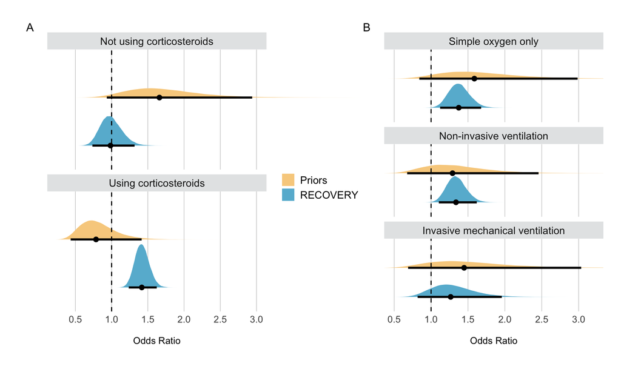

Point estimates depict the median and interval bars depict 95th quantiles.

```r
p1 + p2 + plot_annotation(tag_levels = 'A')
```

```r
# ggsave(width = 10,
#        height = 6,
#        here("final_analyses", "output", "plots", "appendix", # File path
#                  "SFigure14_discharge_figure1.pdf")) # File name
```

Here are the 95% quantile intervals in *odds ratio* for each distribution from the figure above.

```r
distributions_cortico %>%
  # make it tidy to be able to use group_by()
  pivot_longer(
    cols = c(RECOVERY_not:Prior_u),
    names_to = "Subgroup", values_to = "samples"
  ) %>%
  # Group by distribution so we can apply median_qi
  group_by(Subgroup) %>%
  # Calculate the median and 95% quantile interval in log-odds ratio
  ggdist::median_qi(.width = 0.95) %>%
  # Select only the relevant columns
  select(Subgroup:.upper) %>%
  # Exponentiate to transform log-odds ratio into odds ratio
  mutate(across(samples:.upper, ~exp(.))) %>%
  mutate(across(samples:.upper, ~round(., 2))) %>%
  mutate(
    Subgroup = case_when(
      str_detect(Subgroup, "_u") ~ "Using",
      str_detect(Subgroup, "_not") ~ "Not using"
    )) %>%
  rename("Median" = samples,
         "Upper limit" = .upper,
         "Lower limit" = .lower) %>%
  kbl(booktabs = T, align = 'c') %>%
  kable_styling(bootstrap_options = "striped", full_width = F) %>%
  pack_rows("Priors", 1, 2) %>%
  pack_rows("RECOVERY", 3, 4) %>%
  add_header_above(c("Use of corticosteroids" = 4))
```

| Use of corticosteroids Subgroup | Use of corticosteroids Median | Use of corticosteroids Lower limit | Use of corticosteroids Upper limit |
| --- | --- | --- | --- |
| **Priors** |  |  |  |
| Not using | 1.66 | 0.93 | 2.94 |
| Using | 0.78 | 0.43 | 1.41 |
| **RECOVERY** |  |  |  |
| Not using | 0.98 | 0.73 | 1.32 |
| Using | 1.42 | 1.24 | 1.62 |

```r
# https://stackoverflow.com/questions/26548495/reorder-rows-using-custom-order
# create a vector with letters in the desired order
x = c("Prior_s", "Prior_n", "Prior_i",
      "RECOVERY_s", "RECOVERY_n", "RECOVERY_i")

distributions_respiratory %>%
  # make it tidy to be able to use group_by()
  pivot_longer(
    cols = c(RECOVERY_i:Prior_s),
    names_to = "Subgroup", values_to = "samples"
  ) %>%
  # Group by distribution so we can apply median_qi
  group_by(Subgroup) %>%
  # Calculate the median and 95% quantile interval in log-odds ratio
  ggdist::median_qi(.width = 0.95) %>%
  # Select only the relevant columns
  select(Subgroup:.upper) %>%
  # Exponentiate to transform log-odds ratio into odds ratio
  mutate(across(samples:.upper, ~exp(.))) %>%
  mutate(across(samples:.upper, ~round(., 2))) %>%
  # Define order
  mutate(Subgroup = factor(Subgroup, levels = x)) %>%
  arrange(Subgroup) %>%
  mutate(
    Subgroup = case_when(
      str_detect(Subgroup, "_s") ~ "Simple oxygen only",
      str_detect(Subgroup, "_n") ~ "Non-invasive ventilation",
      str_detect(Subgroup, "_i") ~ "Invasive mechanical ventilation"
    )) %>%
  rename("Median" = samples,
         "Upper limit" = .upper,
         "Lower limit" = .lower) %>%
  kbl(booktabs = T, align = 'c') %>%
  kable_styling(bootstrap_options = "striped", full_width = F) %>%
  pack_rows("Priors", 1, 3) %>%
  pack_rows("RECOVERY", 4, 6) %>%
  add_header_above(c("Respiratory support" = 4))
```

| Respiratory support Subgroup | Respiratory support Median | Respiratory support Lower limit | Respiratory support Upper limit |
| --- | --- | --- | --- |
| **Priors** |  |  |  |
| Simple oxygen only | 1.59 | 0.84 | 2.99 |
| Non-invasive ventilation | 1.29 | 0.68 | 2.46 |
| Invasive mechanical ventilation | 1.45 | 0.69 | 3.03 |
| **RECOVERY** |  |  |  |
| Simple oxygen only | 1.37 | 1.12 | 1.68 |
| Non-invasive ventilation | 1.34 | 1.11 | 1.62 |
| Invasive mechanical ventilation | 1.27 | 0.82 | 1.96 |

### Posteriors distributions

```r
# Create data frame

posterior_not_using =
  samples_posteriors_not_using_discharge %>%
  filter(`Underlying_Prior` == "Evidence-based") %>%
  select(`RD`) %>%
  rename("RD_not" = `RD`)

posterior_using =
  samples_posteriors_using_discharge %>%
  filter(`Underlying_Prior` == "Evidence-based") %>%
  select(`RD`) %>%
  rename("RD_u" = `RD`)

distributions_cortico_posterior =
  bind_cols(posterior_not_using,
            posterior_using)
```

```r
p1 = distributions_cortico_posterior %>%
  # make it tidy for ggplot
  pivot_longer(
    cols = c(RD_not:RD_u),
    names_to = "dist", values_to = "samples"
  ) %>%
  mutate(
    # Create new column to be able to use facet at the end
    subgroup = case_when(
      str_detect(dist, "_u") ~ "Using corticosteroids",
      str_detect(dist, "_not") ~ "Not using corticosteroids"
    ),

    # Set order of subgroups
    subgroup = factor(subgroup,
      levels = c(
        "Not using corticosteroids",
        "Using corticosteroids"
      )
    )) %>%

  # Plot!
  ggplot(aes(
    # Multiply by 100 to report in percentage
    x = 100 * samples, y = dist,
    fill = subgroup
  )) +

  # https://mjskay.github.io/ggdist/articles/slabinterval.html
  stat_halfeye(point_interval = median_hdi, # Highest density interval
               .width = c(0.50, 0.95),
               # https://github.com/mjskay/ggdist/issues/70
               interval_size_range = c(1.1,1.9)) +
  scale_fill_manual(values = c("#9EA45B", "#A65041")) +
  geom_vline(xintercept = 0, linetype = 2, size = 0.6) +
  labs(
    x = "\nRisk Difference (%)",
    y = " "
  ) +
  scale_x_continuous(breaks = seq(from = -15, to = 5, 2.5)) +
  coord_cartesian(xlim = c(-15, 5)) +
  scale_y_discrete(expand = c(0, 0.5)) +
  theme(
    strip.background = element_rect(fill = "#E4E6E7"),
    strip.text.x = element_text(size = 12),
    axis.ticks.x = element_blank(),
    axis.ticks.y = element_blank(),
    axis.text.x = element_text(size = 11),
    axis.text.y = element_blank(),
    panel.background = element_blank(),
    panel.grid.major.x = element_line(color = "gray80", size = 0.3),
    legend.position = 'none',
    plot.margin = margin(20, 10, 20, 10)
  ) +
  facet_wrap(~subgroup, ncol = 1, scales = "free_y")
```

```r
# Create data frame

# Simple oxygen only

posterior_s =
  samples_posteriors_simple_discharge %>%
  filter(`Underlying_Prior` == "Evidence-based") %>%
  select(`RD`) %>%
  rename("RD_s" = `RD`)

# Non-invasive ventilation

posterior_n =
  samples_posteriors_noninvasive_discharge %>%
  filter(`Underlying_Prior` == "Evidence-based") %>%
  select(`RD`) %>%
  rename("RD_n" = `RD`)

# Invasive mechanical ventilation

posterior_i =
  samples_posteriors_invasive_discharge %>%
  filter(`Underlying_Prior` == "Evidence-based") %>%
  select(`RD`) %>%
  rename("RD_i" = `RD`)

# Bind altogether

distributions_respiratory_posterior = bind_cols(
  posterior_i,
  posterior_n,
  posterior_s
)
```

```r
p3 = distributions_respiratory_posterior %>%
  # make it tidy for ggplot
  pivot_longer(
    cols = c(RD_i:RD_s),
    names_to = "dist", values_to = "samples"
  ) %>%
  mutate(
    # Create new column to be able to use facet at the end
    subgroup = case_when(
      str_detect(dist, "_s") ~ "Simple oxygen only",
      str_detect(dist, "_n") ~ "Non-invasive ventilation",
      str_detect(dist, "_i") ~ "Invasive mechanical ventilation"
    ),

    # Set order of subgroups
    subgroup = factor(subgroup,
      levels = c(
        "Simple oxygen only",
        "Non-invasive ventilation",
        "Invasive mechanical ventilation"
      ))
    ) %>%
  # Plot!
  ggplot(aes(
    # Multiply by 100 to report in percentage
    x = 100 * samples, y = dist,
    fill = subgroup
  )) +

  # https://mjskay.github.io/ggdist/articles/slabinterval.html
  stat_halfeye(point_interval = median_hdi, # Highest density interval
               .width = c(0.50, 0.95),
               # https://github.com/mjskay/ggdist/issues/70
               interval_size_range = c(1.1,1.9)) +
  scale_fill_manual(values = c("#D9BC8C", # Simple oxyge
                               "#9d95c6", # Non-invasive
                               "#7D8D87") # Invasive
                    ) +
  geom_vline(xintercept = 0, linetype = 2, size = 0.6) +
  labs(
    x = "\nRisk Difference (%)",
    y = " "
  ) +
  scale_x_continuous(breaks = seq(from = -15, to = 5, 2.5)) +
  coord_cartesian(xlim = c(-15, 5)) +
  scale_y_discrete(expand = c(0, 0.5)) +
  theme(
    strip.background = element_rect(fill = "#E4E6E7"),
    strip.text.x = element_text(size = 12),
    axis.ticks.x = element_blank(),
    axis.ticks.y = element_blank(),
    axis.text.x = element_text(size = 11),
    axis.text.y = element_blank(),
    panel.background = element_blank(),
    panel.grid.major.x = element_line(color = "gray80", size = 0.3),
    legend.position = 'none',
    plot.margin = margin(20, 10, 20, 10)
  ) +
  facet_wrap(~ subgroup, ncol = 1, scales = "free_y")
```

```r
p4 = distributions_respiratory_posterior %>%
  # make it tidy for ggplot
  pivot_longer(
    cols = c(RD_i:RD_s),
    names_to = "dist", values_to = "samples"
  ) %>%
  mutate(
    # Create new column to be able to use facet at the end
    subgroup = case_when(
      str_detect(dist, "_s") ~ "Simple oxygen only",
      str_detect(dist, "_n") ~ "Non-invasive ventilation",
      str_detect(dist, "_i") ~ "Invasive mechanical ventilation"
    ),

    # Set order of subgroups
    subgroup = factor(subgroup,
      levels = c(
        "Simple oxygen only",
        "Non-invasive ventilation",
        "Invasive mechanical ventilation"
      ))
    ) %>%
# Multiply by 100 to report in percentage
ggplot(aes(100*samples, colour = subgroup)) +
  stat_ecdf(geom = "step", size = 1.2) +
  scale_color_manual(' ',
                    values = c("#D9BC8C", # Simple oxyge
                               "#9d95c6", # Non-invasive
                               "#7D8D87") # Invasive
                    ) +
  geom_vline(xintercept = 0, linetype = 2, size = 0.6) +
    labs(
      x = "\nRisk Difference (%)",
      y = "Probability RD \u2264 X\n"
      ) +
    scale_x_continuous(
      breaks = seq(from = -15, to = 10, 1),
      limits = c(-15, 10)) +
    scale_y_continuous(
      breaks = seq(from = 0, to = 1, .1),
      expand = c(0, .03)
    ) +
  theme(
      axis.ticks.x = element_blank(),
      panel.background = element_blank(),
      panel.grid.major.x = element_line(color = "gray80", size = 0.3),
      panel.grid.major.y = element_line(color = "gray80", size = 0.3),
      legend.position = 'none',
      plot.margin = margin(20, 10, 20, 10)
    ) +
  coord_cartesian(x = c(-12.5,0.1))
```

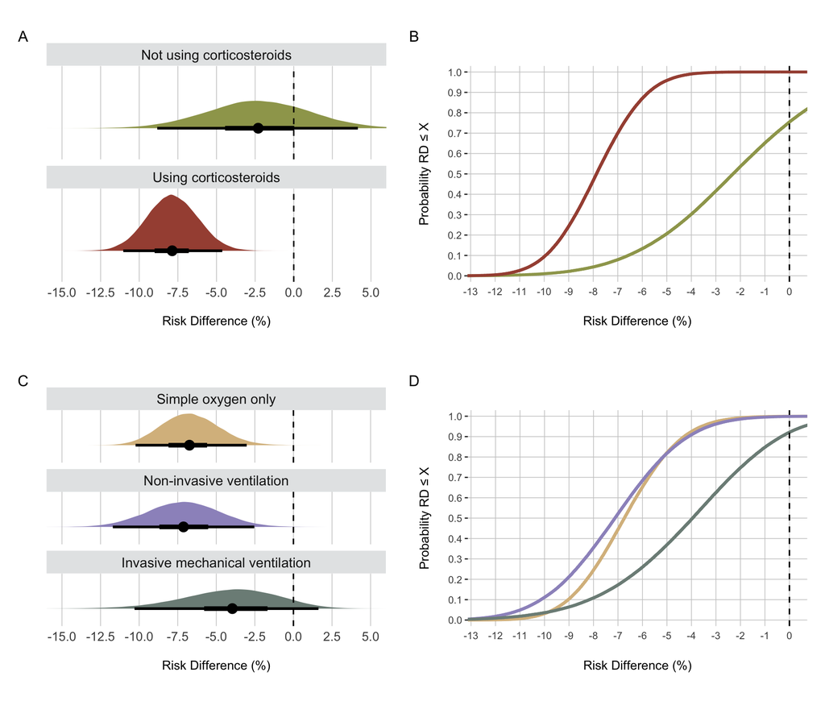

Panels A and C: Point estimates depict the median. Interval bars depict the 50 and 95% highest density intervals. Panels B and D: Cumulative posterior distributions correspond to the probabilities that the risk difference (RD) is less than or equal to the effect size on the X‐axis.

```r
(p1 + p2) / (p3 + p4) + plot_annotation(tag_levels = 'A')
```

```r
# ggsave(width = 10,
#        height = 8.5,
#  #https://stackoverflow.com/questions/12768176/unicode-characters-in-ggplot2-pdf-output
#         device=cairo_pdf,
#         here("final_analyses", "output", "plots", "appendix", # File path
#                   "SFigure15_discharge_figure2.pdf")) # File name
```

```r
multiply100 = function(x){x*100}

t1 = distributions_cortico_posterior %>%
  # make it tidy to be able to use group_by()
  pivot_longer(
    cols = c(RD_not:RD_u),
    names_to = "Subgroup", values_to = "samples"
  ) %>%
  group_by(Subgroup) %>%
  summarise("Pr(\u2264 0%)" = (sum( samples <= 0))/ n(),
            "Pr(\u2264 -1%)" = (sum( samples <= -0.01))/ n(),
            "Pr(\u2264 -2%)" = (sum( samples <= -0.02))/ n(),
            "Pr(\u2264 -5%)" = (sum( samples <= -0.05))/ n()) %>%
  mutate(across(-Subgroup, ~multiply100(.))) %>%
  mutate(across(-Subgroup, ~round(.,1))) %>%
  mutate(
    Subgroup = case_when(
      str_detect(Subgroup, "_u") ~ "Using",
      str_detect(Subgroup, "_not") ~ "Not using"
    ))
```

```r
multiply100 = function(x){x*100}
t2 = distributions_cortico_posterior %>%
  # make it tidy to be able to use group_by()
  pivot_longer(
    cols = c(RD_not:RD_u),
    names_to = "Subgroup", values_to = "samples"
  ) %>%
  # Group by distribution so we can apply median_hdi
  group_by(Subgroup) %>%
  # Calculate the median and 95% quantile interval in log-odds ratio
  ggdist::median_hdi(.width = 0.95) %>%
  # Select only the relevant columns
  select(Subgroup:.upper) %>%
  mutate(across(samples:.upper, ~multiply100(.))) %>%
  mutate(across(samples:.upper, ~round(., 2))) %>%
  rename("Median" = samples,
         "Upper limit" = .upper,
         "Lower limit" = .lower) %>%
  mutate(
    Subgroup = case_when(
      str_detect(Subgroup, "_u") ~ "Using",
      str_detect(Subgroup, "_not") ~ "Not using"
    ))
```

```r
multiply100 = function(x){x*100}

t3 = distributions_respiratory_posterior %>%
  # make it tidy to be able to use group_by()
  pivot_longer(
    cols = c(RD_i:RD_s),
    names_to = "Subgroup", values_to = "samples"
  ) %>%
  group_by(Subgroup) %>%
  summarise("Pr(\u2264 0%)" = (sum( samples <= 0))/ n(),
            "Pr(\u2264 -1%)" = (sum( samples <= -0.01))/ n(),
            "Pr(\u2264 -2%)" = (sum( samples <= -0.02))/ n(),
            "Pr(\u2264 -5%)" = (sum( samples <= -0.05))/ n()) %>%
  mutate(across(-Subgroup, ~multiply100(.))) %>%
  mutate(across(-Subgroup, ~round(.,1))) %>%
  arrange(desc(Subgroup)) %>%
  mutate(
    Subgroup = case_when(
      str_detect(Subgroup, "_s") ~ "Simple oxygen only",
      str_detect(Subgroup, "_n") ~ "Non-invasive ventilation",
      str_detect(Subgroup, "_i") ~ "Invasive mechanical ventilation"
    ))
```

```r
multiply100 = function(x){x*100}

t4 = distributions_respiratory_posterior %>%
  # make it tidy to be able to use group_by()
  pivot_longer(
    cols = c(RD_i:RD_s),
    names_to = "Subgroup", values_to = "samples"
  ) %>%
  # Group by distribution so we can apply median_hdi
  group_by(Subgroup) %>%
  # Calculate the median and 95% quantile interval in log-odds ratio
  ggdist::median_hdi(.width = 0.95) %>%
  # Select only the relevant columns
  select(Subgroup:.upper) %>%
  mutate(across(samples:.upper, ~multiply100(.))) %>%
  mutate(across(samples:.upper, ~round(., 2))) %>%
  rename("Median" = samples,
         "Upper limit" = .upper,
         "Lower limit" = .lower) %>%
  arrange(desc(Subgroup)) %>%
  mutate(
    Subgroup = case_when(
      str_detect(Subgroup, "_s") ~ "Simple oxygen only",
      str_detect(Subgroup, "_n") ~ "Non-invasive ventilation",
      str_detect(Subgroup, "_i") ~ "Invasive mechanical ventilation"
    ))
```

Here are the posterior probabilities for each posterior distribution.

```r
bind_rows(t1,t3) %>%
  kbl(booktabs = T, align = 'c') %>%
  kable_styling(bootstrap_options = "striped", full_width = F) %>%
  pack_rows("Use of corticosteroids", 1, 2) %>%
  pack_rows("Respiratory support", 3, 5) %>%
  add_header_above(c(" " = 1,
                     "Probability of Risk Difference \u2265 X%" = 4))
```

| Subgroup | Probability of Risk Difference ≥ X% Pr(≤ 0%) | Probability of Risk Difference ≥ X% Pr(≤ -1%) | Probability of Risk Difference ≥ X% Pr(≤ -2%) | Probability of Risk Difference ≥ X% Pr(≤ -5%) |
| --- | --- | --- | --- | --- |
| **Use of corticosteroids** |  |  |  |  |
| Not using | 75.4 | 65.1 | 53.6 | 20.7 |
| Using | 100.0 | 100.0 | 100.0 | 95.8 |
| **Respiratory support** |  |  |  |  |
| Simple oxygen only | 100.0 | 99.8 | 99.2 | 82.1 |
| Non-invasive ventilation | 99.9 | 99.6 | 98.6 | 81.8 |
| Invasive mechanical ventilation | 92.1 | 84.8 | 74.7 | 37.0 |

Here are the 95% HDI in *risk difference* of each posterior distribution.

```r
bind_rows(t2,t4) %>%
  kbl(booktabs = T, align = 'c') %>%
  kable_styling(bootstrap_options = "striped", full_width = F) %>%
  pack_rows("Use of corticosteroids", 1, 2) %>%
  pack_rows("Respiratory support", 3, 5) %>%
  add_header_above(c(" " = 1,
                     "95% Highest Density Interval" = 3))
```

| Subgroup | 95% Highest Density Interval Median | 95% Highest Density Interval Lower limit | 95% Highest Density Interval Upper limit |
| --- | --- | --- | --- |
| **Use of corticosteroids** |  |  |  |
| Not using | -2.30 | -8.84 | 4.15 |
| Using | -7.87 | -11.04 | -4.63 |
| **Respiratory support** |  |  |  |
| Simple oxygen only | -6.74 | -10.23 | -3.03 |
| Non-invasive ventilation | -7.13 | -11.71 | -2.54 |
| Invasive mechanical ventilation | -3.96 | -10.30 | 1.62 |

## Sensitivity analyses: different priors

### Not using corticosteroids

#### Prior and likelihood distributions

```r
distributions =
  tibble(

    "RECOVERY (likelihood)" = list(
      rnorm(
        10e4,
        mean = (posteriors_not_using_discharge %>%
                # Data.mean and data.sd are all the same in every row
                # So it doesn't matter what row I slice
                slice(1) %>%
                pull(data.mean)),
        sd = (posteriors_not_using_discharge %>%
              slice(1) %>%
              pull(data.sd))
    )),

    "Non-informative prior" = list(
      rnorm(
        10e4,
        mean = (posteriors_not_using_discharge %>%
                filter(type == "non-informative") %>%
                pull(prior.mean)),
        sd = (posteriors_not_using_discharge %>%
              filter(type == "non-informative") %>%
              pull(prior.sd))
    )),

    "Evidence-based prior" = list(
      rnorm(
        10e4,
        mean = (posteriors_not_using_discharge %>%
                filter(type == "evidence-based") %>%
                pull(prior.mean)),
        sd = (posteriors_not_using_discharge %>%
              filter(type == "evidence-based") %>%
              pull(prior.sd))
    )),

    "Skeptical prior" = list(
      rnorm(
        10e4,
        mean = (posteriors_not_using_discharge %>%
                filter(type == "skeptical") %>%
                pull(prior.mean)),
        sd = (posteriors_not_using_discharge %>%
              filter(type == "skeptical") %>%
              pull(prior.sd))
    )),

    "Optimistic prior" = list(
      rnorm(
        10e4,
        mean = (posteriors_not_using_discharge %>%
                filter(type == "optimistic") %>%
                pull(prior.mean)),
        sd = (posteriors_not_using_discharge %>%
              filter(type == "optimistic") %>%
              pull(prior.sd))
    )),

    "Pessimistic prior" = list(
      rnorm(
        10e4,
        mean = (posteriors_not_using_discharge %>%
                filter(type == "pessimistic") %>%
                pull(prior.mean)),
        sd = (posteriors_not_using_discharge %>%
              filter(type == "pessimistic") %>%
              pull(prior.sd))
    ))
  ) %>%
  unnest(everything())
```

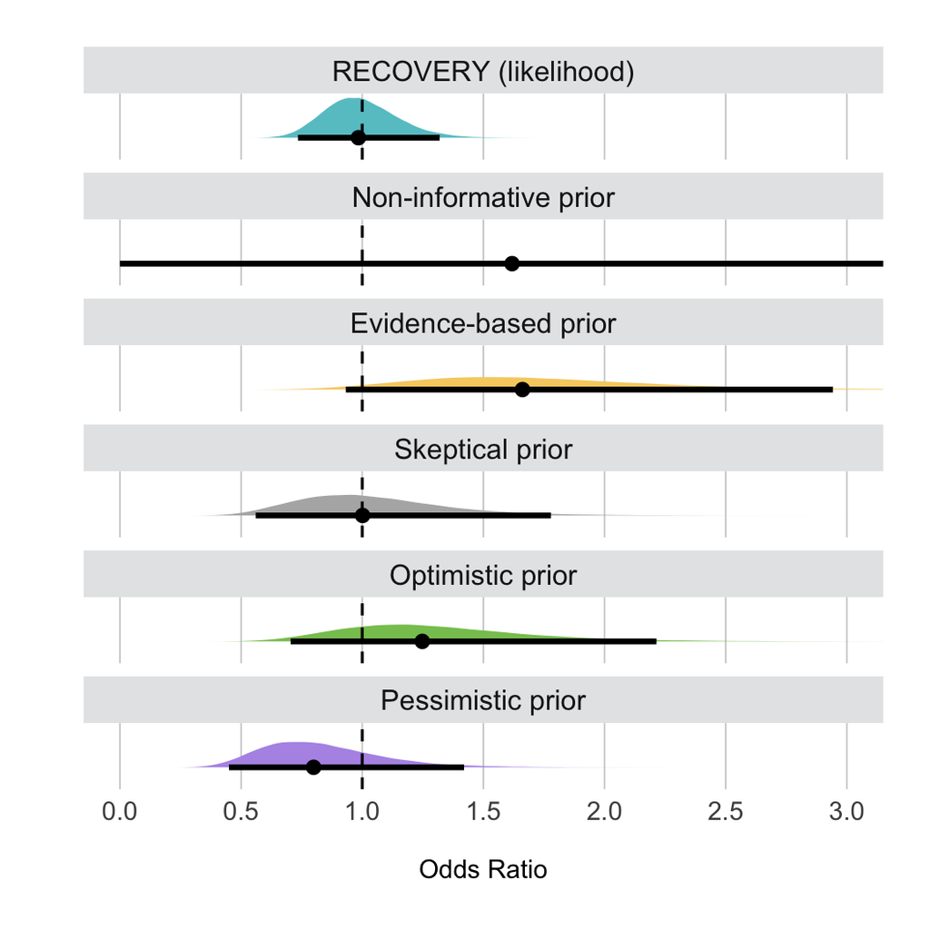

```r
# Plot!

distributions %>%
  # make it tidy for ggplot
  pivot_longer(
    cols = c(everything()),
    names_to = "dist", values_to = "samples"
  ) %>%
  # Set order of priors
  mutate(dist = factor(dist, levels =
                         c("RECOVERY (likelihood)",
                           "Non-informative prior",
                           "Evidence-based prior",
                           "Skeptical prior",
                           "Optimistic prior",
                           "Pessimistic prior")
                       )
         ) %>%
  # exp() to transform log(OR) to OR
  ggplot(aes(
    x = exp(samples), y = dist,
    fill = dist
  )) +

  # https://mjskay.github.io/ggdist/articles/slabinterval.html
  stat_halfeye(position = "dodge",
               point_interval = median_qi, # Quantile interval
               .width = c(0.95)) +
  geom_vline(xintercept = 1, linetype = 2, size = 0.6) +
  scale_fill_manual(' ',
                    values = c(
    carto_pal(12, "Pastel")[1], # RECOVERY
    carto_pal(12, "Pastel")[12], # Non-informative,
    carto_pal(12, "Pastel")[2], # Evidence-based
    "gray70", # Skeptical
    carto_pal(12, "Pastel")[5], # Optimistic
    carto_pal(12, "Pastel")[10]  # Pessimistc
  )) +
  labs(
    x = "\nOdds Ratio",
    y = " "
  ) +
  scale_x_continuous(breaks = seq(from = 0, to = 3, 0.5)) +
  scale_y_discrete(expand = c(0, 0.5)) +
  theme(
    strip.background = element_rect(fill = "#E4E6E7"),
    strip.text.x = element_text(size = 12),
    axis.ticks.x = element_blank(),
    axis.ticks.y = element_blank(),
    axis.text.x = element_text(size = 11),
    axis.text.y = element_blank(),
    panel.background = element_blank(),
    panel.grid.major.x = element_line(color = "gray80", size = 0.3),
    legend.position = 'none',
    legend.text = element_text(size=12),
    legend.key= element_blank(),
    plot.margin = margin(20, 20, 20, 20)
  ) +
  coord_cartesian(x = c(0, 3)) +
  facet_wrap(~dist, ncol = 1, scales = "free_y")
```

#### Posterior distributions

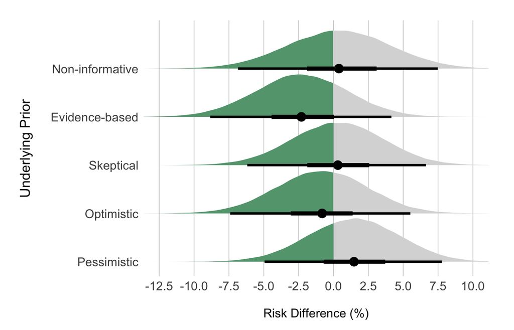

Point estimates depict the median. Interval bars depict the 50 and 95% highest density intervals.

```r
level_order = c("Pessimistic",
                "Optimistic",
                "Skeptical",
                "Evidence-based",
                "Non-informative")

samples_posteriors_not_using_discharge %>%

  ggplot(aes(
    # Multiply by 100 to report in percentage
    x = 100 * RD,
    y = factor(`Underlying_Prior`, level = level_order),
    fill = `Underlying_Prior`)) +

  # https://mjskay.github.io/ggdist/articles/slabinterval.html
    stat_halfeye(aes(fill = stat(x < 0)),
                 position = "dodge",
               point_interval = median_hdi, # Highest density interval
               .width = c(0.5, 0.95),
               # https://github.com/mjskay/ggdist/issues/70
               interval_size_range = c(1.1,1.9)
  ) +
  scale_fill_manual(values = c("gray85", "#64A37E")) +
  labs(x = "\nRisk Difference (%)",
       y = "Underlying Prior\n"
  ) +
  scale_x_continuous(breaks = seq(from = -12.5, to = 10, 2.5)) +
  scale_y_discrete(expand = c(0, 0.3)) +
  theme(axis.title.x = element_text(size = 12),
    axis.title.y = element_text(size = 13.5),
    axis.text.y = element_text(size = 12),
    axis.text.x = element_text(size = 12),
    axis.ticks.x = element_blank(),
    axis.ticks.y = element_blank(),
    panel.background = element_blank(),
    panel.grid.major.x = element_line(color = "gray80", size = 0.3),
    legend.position = "none",
    plot.title.position = 'plot',
    plot.margin = margin(20, 25, 10, 20)
  ) +
  coord_cartesian(xlim = c(-12.5, 10))
```

```r
# ggsave(width = 7,
#        height = 4.5,
#         here("final_analyses", "output", "plots", "appendix", # File path
#                   "SFigure16_discharge_posteriors_not_using.pdf")) # File name
```

```r
t = tibble(

  "Underlying Prior" = c(
    "Non-informative",
    "Evidence-based",
    "Skeptical",
    "Optimistic",
    "Pessimistic"
  ),


  "Pr(< -5%)" = c(round((samples_posteriors_not_using_discharge %>%
                           filter(`Underlying_Prior` == "Non-informative") %>%
                           summarise(n = sum(RD < -0.05) / n()) %>%
                           pull()), 2) * 100,

                  round((samples_posteriors_not_using_discharge %>%
                           filter(`Underlying_Prior` == "Evidence-based") %>%
                           summarise(n = sum(RD < -0.05) / n()) %>%
                           pull()), 2) * 100,

                  round((samples_posteriors_not_using_discharge %>%
                           filter(`Underlying_Prior` == "Skeptical") %>%
                           summarise(n = sum(RD < -0.05) / n()) %>%
                           pull()), 2) * 100,

                  round((samples_posteriors_not_using_discharge %>%
                           filter(`Underlying_Prior` == "Optimistic") %>%
                           summarise(n = sum(RD < -0.05) / n()) %>%
                           pull()), 2) * 100,

                  round((samples_posteriors_not_using_discharge %>%
                           filter(`Underlying_Prior` == "Pessimistic") %>%
                           summarise(n = sum(RD < -0.05) / n()) %>%
                           pull()), 2) * 100
  ),

  "Pr(< -2%)" = c(round((samples_posteriors_not_using_discharge %>%
                           filter(`Underlying_Prior` == "Non-informative") %>%
                           summarise(n = sum(RD < -0.02) / n()) %>%
                           pull()), 2) * 100,

                  round((samples_posteriors_not_using_discharge %>%
                           filter(`Underlying_Prior` == "Evidence-based") %>%
                           summarise(n = sum(RD < -0.02) / n()) %>%
                           pull()), 2) * 100,

                  round((samples_posteriors_not_using_discharge %>%
                           filter(`Underlying_Prior` == "Skeptical") %>%
                           summarise(n = sum(RD < -0.02) / n()) %>%
                           pull()), 2) * 100,

                  round((samples_posteriors_not_using_discharge %>%
                           filter(`Underlying_Prior` == "Optimistic") %>%
                           summarise(n = sum(RD < -0.02) / n()) %>%
                           pull()), 2) * 100,

                  round((samples_posteriors_not_using_discharge %>%
                           filter(`Underlying_Prior` == "Pessimistic") %>%
                           summarise(n = sum(RD < -0.02) / n()) %>%
                           pull()), 2) * 100
  ),

  "Pr(< -1%)" = c(round((samples_posteriors_not_using_discharge %>%
                           filter(`Underlying_Prior` == "Non-informative") %>%
                           summarise(n = sum(RD < -0.01) / n()) %>%
                           pull()), 2) * 100,

                  round((samples_posteriors_not_using_discharge %>%
                           filter(`Underlying_Prior` == "Evidence-based") %>%
                           summarise(n = sum(RD < -0.01) / n()) %>%
                           pull()), 2) * 100,

                  round((samples_posteriors_not_using_discharge %>%
                           filter(`Underlying_Prior` == "Skeptical") %>%
                           summarise(n = sum(RD < -0.01) / n()) %>%
                           pull()), 2) * 100,

                  round((samples_posteriors_not_using_discharge %>%
                           filter(`Underlying_Prior` == "Optimistic") %>%
                           summarise(n = sum(RD < -0.01) / n()) %>%
                           pull()), 2) * 100,

                  round((samples_posteriors_not_using_discharge %>%
                           filter(`Underlying_Prior` == "Pessimistic") %>%
                           summarise(n = sum(RD < -0.01) / n()) %>%
                           pull()), 2) * 100
  ),


  "Pr(< 0%)" = c(round((samples_posteriors_not_using_discharge %>%
                          filter(`Underlying_Prior` == "Non-informative") %>%
                          summarise(n = sum(RD < 0) / n()) %>%
                          pull()), 2) * 100,

                 round((samples_posteriors_not_using_discharge %>%
                          filter(`Underlying_Prior` == "Evidence-based") %>%
                          summarise(n = sum(RD < 0) / n()) %>%
                          pull()), 2) * 100,

                 round((samples_posteriors_not_using_discharge %>%
                          filter(`Underlying_Prior` == "Skeptical") %>%
                          summarise(n = sum(RD < 0) / n()) %>%
                          pull()), 2) * 100,

                 round((samples_posteriors_not_using_discharge %>%
                          filter(`Underlying_Prior` == "Optimistic") %>%
                          summarise(n = sum(RD < 0) / n()) %>%
                          pull()), 2) * 100,

                 round((samples_posteriors_not_using_discharge %>%
                          filter(`Underlying_Prior` == "Pessimistic") %>%
                          summarise(n = sum(RD < 0) / n()) %>%
                          pull()), 2) * 100
  ),

  "Pr(> 1%)" = c(round((samples_posteriors_not_using_discharge %>%
                          filter(`Underlying_Prior` == "Non-informative") %>%
                          summarise(n = sum(RD > 0.01) / n()) %>%
                          pull()), 2) * 100,

                 round((samples_posteriors_not_using_discharge %>%
                          filter(`Underlying_Prior` == "Evidence-based") %>%
                          summarise(n = sum(RD > 0.01) / n()) %>%
                          pull()), 2) * 100,

                 round((samples_posteriors_not_using_discharge %>%
                          filter(`Underlying_Prior` == "Skeptical") %>%
                          summarise(n = sum(RD > 0.01) / n()) %>%
                          pull()), 2) * 100,

                 round((samples_posteriors_not_using_discharge %>%
                          filter(`Underlying_Prior` == "Optimistic") %>%
                          summarise(n = sum(RD > 0.01) / n()) %>%
                          pull()), 2) * 100,

                 round((samples_posteriors_not_using_discharge %>%
                          filter(`Underlying_Prior` == "Pessimistic") %>%
                          summarise(n = sum(RD > 0.01) / n()) %>%
                          pull()), 2) * 100
  ),

  "Pr(> 2%)" = c(round((samples_posteriors_not_using_discharge %>%
                          filter(`Underlying_Prior` == "Non-informative") %>%
                          summarise(n = sum(RD > 0.02) / n()) %>%
                          pull()), 2) * 100,

                 round((samples_posteriors_not_using_discharge %>%
                          filter(`Underlying_Prior` == "Evidence-based") %>%
                          summarise(n = sum(RD > 0.02) / n()) %>%
                          pull()), 2) * 100,

                 round((samples_posteriors_not_using_discharge %>%
                          filter(`Underlying_Prior` == "Skeptical") %>%
                          summarise(n = sum(RD > 0.02) / n()) %>%
                          pull()), 2) * 100,

                 round((samples_posteriors_not_using_discharge %>%
                          filter(`Underlying_Prior` == "Optimistic") %>%
                          summarise(n = sum(RD > 0.02) / n()) %>%
                          pull()), 2) * 100,

                 round((samples_posteriors_not_using_discharge %>%
                          filter(`Underlying_Prior` == "Pessimistic") %>%
                          summarise(n = sum(RD > 0.02) / n()) %>%
                          pull()), 2) * 100
  ),

  "Pr(> 5%)" = c(round((samples_posteriors_not_using_discharge %>%
                          filter(`Underlying_Prior` == "Non-informative") %>%
                          summarise(n = sum(RD > 0.05) / n()) %>%
                          pull()), 2) * 100,

                 round((samples_posteriors_not_using_discharge %>%
                          filter(`Underlying_Prior` == "Evidence-based") %>%
                          summarise(n = sum(RD > 0.05) / n()) %>%
                          pull()), 2) * 100,

                 round((samples_posteriors_not_using_discharge %>%
                          filter(`Underlying_Prior` == "Skeptical") %>%
                          summarise(n = sum(RD > 0.05) / n()) %>%
                          pull()), 2) * 100,

                 round((samples_posteriors_not_using_discharge %>%
                          filter(`Underlying_Prior` == "Optimistic") %>%
                          summarise(n = sum(RD > 0.05) / n()) %>%
                          pull()), 2) * 100,

                 round((samples_posteriors_not_using_discharge %>%
                          filter(`Underlying_Prior` == "Pessimistic") %>%
                          summarise(n = sum(RD > 0.05) / n()) %>%
                          pull()), 2) * 100
  )
)

t1 = t %>%
  kbl(booktabs = T, align = 'c') %>%
  kable_styling(bootstrap_options = "striped", full_width = F) %>%
  add_header_above(c(" " = 1,
                     "Probability of Benefit" = 4,
                     "Probability of Harm" = 3))

t1
```

| Underlying Prior | Probability of Benefit Pr(< -5%) | Probability of Benefit Pr(< -2%) | Probability of Benefit Pr(< -1%) | Probability of Benefit Pr(< 0%) | Probability of Harm Pr(> 1%) | Probability of Harm Pr(> 2%) | Probability of Harm Pr(> 5%) |
| --- | --- | --- | --- | --- | --- | --- | --- |
| Non-informative | 7 | 26 | 35 | 46 | 43 | 33 | 10 |
| Evidence-based | 21 | 54 | 65 | 75 | 16 | 10 | 1 |
| Skeptical | 5 | 24 | 35 | 46 | 42 | 30 | 7 |
| Optimistic | 10 | 36 | 48 | 60 | 29 | 20 | 4 |
| Pessimistic | 2 | 15 | 23 | 33 | 56 | 43 | 14 |

```r
t1 %>%
  save_kable(here("final_analyses", "output", "plots", "appendix", # File path
                  "STable14_discharge_probabilities_not_using.pdf")) # File name
```

```
## Note that HTML color may not be displayed on PDF properly.
```

##### HDI for each posterior distribution

Here are the 95% HDI in *risk difference* of each distribution.

```r
multiply100 = function(x){x*100}

samples_posteriors_not_using_discharge %>%
  select("Underlying_Prior", "RD") %>%
  # Group by distribution so we can apply median_hdi
  group_by(`Underlying_Prior`) %>%
  # Calculate the median and 95% quantile interval in log-odds ratio
  ggdist::median_hdi(.width = 0.95) %>%
  # Select only the relevant columns
  # Arrange order
  arrange(factor(`Underlying_Prior`, levels = c(
    "Non-informative",
    "Evidence-based",
    "Skeptical",
    "Optimistic",
    "Pessimistic"
    ))) %>%
  select("Underlying_Prior":.upper) %>%
  mutate(across(RD:.upper, ~multiply100(.))) %>%
  mutate(across(RD:.upper, ~round(., 2))) %>%
  rename("Underlying Prior" = Underlying_Prior,
         "Median" = RD,
         "Upper limit" = .upper,
         "Lower limit" = .lower) %>%
  kbl(booktabs = T, align = 'c') %>%
  kable_styling(bootstrap_options = "striped", full_width = F) %>%
  add_header_above(c(" " = 1,
                     "95% Highest Density Interval" = 3))
```

| Underlying Prior | 95% Highest Density Interval Median | 95% Highest Density Interval Lower limit | 95% Highest Density Interval Upper limit |
| --- | --- | --- | --- |
| Non-informative | 0.39 | -6.85 | 7.48 |
| Evidence-based | -2.30 | -8.84 | 4.15 |
| Skeptical | 0.31 | -6.19 | 6.64 |
| Optimistic | -0.82 | -7.41 | 5.51 |
| Pessimistic | 1.47 | -4.95 | 7.77 |

### Using corticosteroids

#### Prior and likelihood distributions

```r
distributions =
  tibble(

    "RECOVERY (likelihood)" = list(
      rnorm(
        10e4,
        mean = (posteriors_using_discharge %>%
                  # Data.mean and data.sd are all the same in every row
                  # So it doesn't matter what row I slice
                  slice(1) %>%
                  pull(data.mean)),
        sd = (posteriors_using_discharge %>%
                slice(1) %>%
                pull(data.sd))
      )),

    "Non-informative prior" = list(
      rnorm(
        10e4,
        mean = (posteriors_using_discharge %>%
                  filter(type == "non-informative") %>%
                  pull(prior.mean)),
        sd = (posteriors_using_discharge %>%
                filter(type == "non-informative") %>%
                pull(prior.sd))
      )),

    "Evidence-based prior" = list(
      rnorm(
        10e4,
        mean = (posteriors_using_discharge %>%
                  filter(type == "evidence-based") %>%
                  pull(prior.mean)),
        sd = (posteriors_using_discharge %>%
                filter(type == "evidence-based") %>%
                pull(prior.sd))
      )),

    "Skeptical prior" = list(
      rnorm(
        10e4,
        mean = (posteriors_using_discharge %>%
                  filter(type == "skeptical") %>%
                  pull(prior.mean)),
        sd = (posteriors_using_discharge %>%
                filter(type == "skeptical") %>%
                pull(prior.sd))
      )),

    "Optimistic prior" = list(
      rnorm(
        10e4,
        mean = (posteriors_using_discharge %>%
                  filter(type == "optimistic") %>%
                  pull(prior.mean)),
        sd = (posteriors_using_discharge %>%
                filter(type == "optimistic") %>%
                pull(prior.sd))
      )),

    "Pessimistic prior" = list(
      rnorm(
        10e4,
        mean = (posteriors_using_discharge %>%
                  filter(type == "pessimistic") %>%
                  pull(prior.mean)),
        sd = (posteriors_using_discharge %>%
                filter(type == "pessimistic") %>%
                pull(prior.sd))
      ))
  ) %>%
  unnest(everything())
```

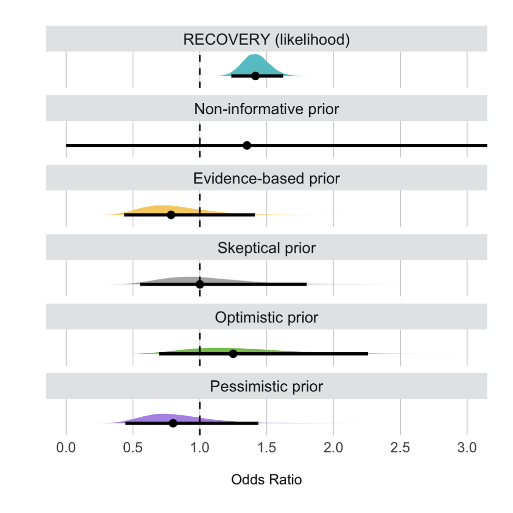

```r
# Plot!

distributions %>%
  # make it tidy for ggplot
  pivot_longer(
    cols = c(everything()),
    names_to = "dist", values_to = "samples"
  ) %>%
  # Set order of priors
  mutate(dist = factor(dist, levels =
                         c("RECOVERY (likelihood)",
                           "Non-informative prior",
                           "Evidence-based prior",
                           "Skeptical prior",
                           "Optimistic prior",
                           "Pessimistic prior")
  )
  ) %>%
  # exp() to transform log(OR) to OR
  ggplot(aes(
    x = exp(samples), y = dist,
    fill = dist
  )) +

  # https://mjskay.github.io/ggdist/articles/slabinterval.html
  stat_halfeye(position = "dodge",
               point_interval = median_qi, # Quantile interval
               .width = c(0.95)) +
  geom_vline(xintercept = 1, linetype = 2, size = 0.6) +
  scale_fill_manual(' ',
                    values = c(
                      carto_pal(12, "Pastel")[1], # RECOVERY
                      carto_pal(12, "Pastel")[12], # Non-informative,
                      carto_pal(12, "Pastel")[2], # Evidence-based
                      "gray70", # Skeptical
                      carto_pal(12, "Pastel")[5], # Optimistic
                      carto_pal(12, "Pastel")[10]  # Pessimistc
                    )) +
  labs(
    x = "\nOdds Ratio",
    y = " "
  ) +
  scale_x_continuous(breaks = seq(from = 0, to = 3, 0.5)) +
  scale_y_discrete(expand = c(0, 0.5)) +
  theme(
    strip.background = element_rect(fill = "#E4E6E7"),
    strip.text.x = element_text(size = 12),
    axis.ticks.x = element_blank(),
    axis.ticks.y = element_blank(),
    axis.text.x = element_text(size = 11),
    axis.text.y = element_blank(),
    panel.background = element_blank(),
    panel.grid.major.x = element_line(color = "gray80", size = 0.3),
    legend.position = 'none',
    legend.text = element_text(size=12),
    legend.key= element_blank(),
    plot.margin = margin(20, 20, 20, 20)
  ) +
  coord_cartesian(x = c(0, 3)) +
  facet_wrap(~dist, ncol = 1, scales = "free_y")
```

#### Posterior distributions

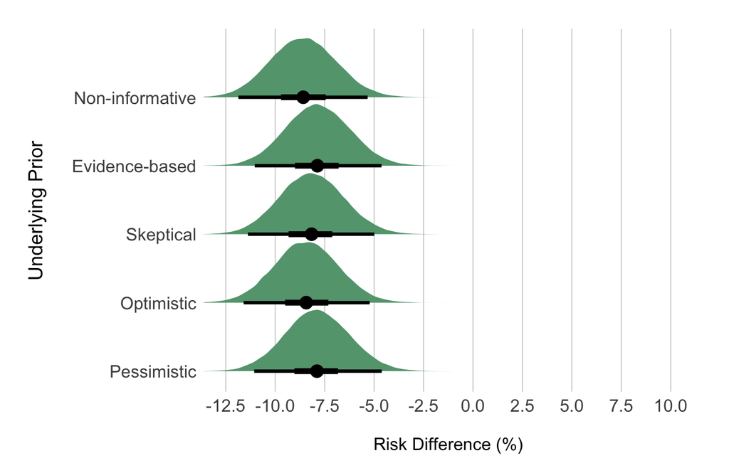

Point estimates depict the median. Interval bars depict the 50 and 95% highest density intervals.

```r
level_order = c("Pessimistic",
                "Optimistic",
                "Skeptical",
                "Evidence-based",
                "Non-informative")

samples_posteriors_using_discharge %>%

  ggplot(aes(
    # Multiply by 100 to report in percentage
    x = 100 * RD,
    y = factor(`Underlying_Prior`, level = level_order),
    fill = `Underlying_Prior`)) +

  # https://mjskay.github.io/ggdist/articles/slabinterval.html
  stat_halfeye(aes(fill = stat(x < 0)),
               position = "dodge",
               point_interval = median_hdi, # Highest density interval
               .width = c(0.5, 0.95),
               # https://github.com/mjskay/ggdist/issues/70
               interval_size_range = c(1.1,1.9)
  ) +
  scale_fill_manual(values = c("gray85", "#64A37E")) +
  labs(x = "\nRisk Difference (%)",
       y = "Underlying Prior\n"
  ) +
  scale_x_continuous(breaks = seq(from = -12.5, to = 10, 2.5)) +
  scale_y_discrete(expand = c(0, 0.3)) +
  theme(axis.title.x = element_text(size = 12),
        axis.title.y = element_text(size = 13.5),
        axis.text.y = element_text(size = 12),
        axis.text.x = element_text(size = 12),
        axis.ticks.x = element_blank(),
        axis.ticks.y = element_blank(),
        panel.background = element_blank(),
        panel.grid.major.x = element_line(color = "gray80", size = 0.3),
        legend.position = "none",
        plot.title.position = 'plot',
        plot.margin = margin(20, 25, 10, 20)
  ) +
  coord_cartesian(xlim = c(-12.5, 10))
```

```r
# ggsave(width = 7,
#        height = 4.5,
#         here("final_analyses", "output", "plots", "appendix", # File path
#                   "SFigure17_discharge_posteriors_using.pdf")) # File name
```

```r
t = tibble(

  "Underlying Prior" = c(
    "Non-informative",
    "Evidence-based",
    "Skeptical",
    "Optimistic",
    "Pessimistic"
  ),


  "Pr(< -5%)" = c(round((samples_posteriors_using_discharge %>%
                           filter(`Underlying_Prior` == "Non-informative") %>%
                           summarise(n = sum(RD < -0.05) / n()) %>%
                           pull()), 2) * 100,

                  round((samples_posteriors_using_discharge %>%
                           filter(`Underlying_Prior` == "Evidence-based") %>%
                           summarise(n = sum(RD < -0.05) / n()) %>%
                           pull()), 2) * 100,

                  round((samples_posteriors_using_discharge %>%
                           filter(`Underlying_Prior` == "Skeptical") %>%
                           summarise(n = sum(RD < -0.05) / n()) %>%
                           pull()), 2) * 100,

                  round((samples_posteriors_using_discharge %>%
                           filter(`Underlying_Prior` == "Optimistic") %>%
                           summarise(n = sum(RD < -0.05) / n()) %>%
                           pull()), 2) * 100,

                  round((samples_posteriors_using_discharge %>%
                           filter(`Underlying_Prior` == "Pessimistic") %>%
                           summarise(n = sum(RD < -0.05) / n()) %>%
                           pull()), 2) * 100
  ),

  "Pr(< -2%)" = c(round((samples_posteriors_using_discharge %>%
                           filter(`Underlying_Prior` == "Non-informative") %>%
                           summarise(n = sum(RD < -0.02) / n()) %>%
                           pull()), 2) * 100,

                  round((samples_posteriors_using_discharge %>%
                           filter(`Underlying_Prior` == "Evidence-based") %>%
                           summarise(n = sum(RD < -0.02) / n()) %>%
                           pull()), 2) * 100,

                  round((samples_posteriors_using_discharge %>%
                           filter(`Underlying_Prior` == "Skeptical") %>%
                           summarise(n = sum(RD < -0.02) / n()) %>%
                           pull()), 2) * 100,

                  round((samples_posteriors_using_discharge %>%
                           filter(`Underlying_Prior` == "Optimistic") %>%
                           summarise(n = sum(RD < -0.02) / n()) %>%
                           pull()), 2) * 100,

                  round((samples_posteriors_using_discharge %>%
                           filter(`Underlying_Prior` == "Pessimistic") %>%
                           summarise(n = sum(RD < -0.02) / n()) %>%
                           pull()), 2) * 100
  ),

  "Pr(< -1%)" = c(round((samples_posteriors_using_discharge %>%
                           filter(`Underlying_Prior` == "Non-informative") %>%
                           summarise(n = sum(RD < -0.01) / n()) %>%
                           pull()), 2) * 100,

                  round((samples_posteriors_using_discharge %>%
                           filter(`Underlying_Prior` == "Evidence-based") %>%
                           summarise(n = sum(RD < -0.01) / n()) %>%
                           pull()), 2) * 100,

                  round((samples_posteriors_using_discharge %>%
                           filter(`Underlying_Prior` == "Skeptical") %>%
                           summarise(n = sum(RD < -0.01) / n()) %>%
                           pull()), 2) * 100,

                  round((samples_posteriors_using_discharge %>%
                           filter(`Underlying_Prior` == "Optimistic") %>%
                           summarise(n = sum(RD < -0.01) / n()) %>%
                           pull()), 2) * 100,

                  round((samples_posteriors_using_discharge %>%
                           filter(`Underlying_Prior` == "Pessimistic") %>%
                           summarise(n = sum(RD < -0.01) / n()) %>%
                           pull()), 2) * 100
  ),


  "Pr(< 0%)" = c(round((samples_posteriors_using_discharge %>%
                          filter(`Underlying_Prior` == "Non-informative") %>%
                          summarise(n = sum(RD < 0) / n()) %>%
                          pull()), 2) * 100,

                 round((samples_posteriors_using_discharge %>%
                          filter(`Underlying_Prior` == "Evidence-based") %>%
                          summarise(n = sum(RD < 0) / n()) %>%
                          pull()), 2) * 100,

                 round((samples_posteriors_using_discharge %>%
                          filter(`Underlying_Prior` == "Skeptical") %>%
                          summarise(n = sum(RD < 0) / n()) %>%
                          pull()), 2) * 100,

                 round((samples_posteriors_using_discharge %>%
                          filter(`Underlying_Prior` == "Optimistic") %>%
                          summarise(n = sum(RD < 0) / n()) %>%
                          pull()), 2) * 100,

                 round((samples_posteriors_using_discharge %>%
                          filter(`Underlying_Prior` == "Pessimistic") %>%
                          summarise(n = sum(RD < 0) / n()) %>%
                          pull()), 2) * 100
  ),

  "Pr(> 1%)" = c(round((samples_posteriors_using_discharge %>%
                          filter(`Underlying_Prior` == "Non-informative") %>%
                          summarise(n = sum(RD > 0.01) / n()) %>%
                          pull()), 2) * 100,

                 round((samples_posteriors_using_discharge %>%
                          filter(`Underlying_Prior` == "Evidence-based") %>%
                          summarise(n = sum(RD > 0.01) / n()) %>%
                          pull()), 2) * 100,

                 round((samples_posteriors_using_discharge %>%
                          filter(`Underlying_Prior` == "Skeptical") %>%
                          summarise(n = sum(RD > 0.01) / n()) %>%
                          pull()), 2) * 100,

                 round((samples_posteriors_using_discharge %>%
                          filter(`Underlying_Prior` == "Optimistic") %>%
                          summarise(n = sum(RD > 0.01) / n()) %>%
                          pull()), 2) * 100,

                 round((samples_posteriors_using_discharge %>%
                          filter(`Underlying_Prior` == "Pessimistic") %>%
                          summarise(n = sum(RD > 0.01) / n()) %>%
                          pull()), 2) * 100
  ),

  "Pr(> 2%)" = c(round((samples_posteriors_using_discharge %>%
                          filter(`Underlying_Prior` == "Non-informative") %>%
                          summarise(n = sum(RD > 0.02) / n()) %>%
                          pull()), 2) * 100,

                 round((samples_posteriors_using_discharge %>%
                          filter(`Underlying_Prior` == "Evidence-based") %>%
                          summarise(n = sum(RD > 0.02) / n()) %>%
                          pull()), 2) * 100,

                 round((samples_posteriors_using_discharge %>%
                          filter(`Underlying_Prior` == "Skeptical") %>%
                          summarise(n = sum(RD > 0.02) / n()) %>%
                          pull()), 2) * 100,

                 round((samples_posteriors_using_discharge %>%
                          filter(`Underlying_Prior` == "Optimistic") %>%
                          summarise(n = sum(RD > 0.02) / n()) %>%
                          pull()), 2) * 100,

                 round((samples_posteriors_using_discharge %>%
                          filter(`Underlying_Prior` == "Pessimistic") %>%
                          summarise(n = sum(RD > 0.02) / n()) %>%
                          pull()), 2) * 100
  ),

  "Pr(> 5%)" = c(round((samples_posteriors_using_discharge %>%
                          filter(`Underlying_Prior` == "Non-informative") %>%
                          summarise(n = sum(RD > 0.05) / n()) %>%
                          pull()), 2) * 100,

                 round((samples_posteriors_using_discharge %>%
                          filter(`Underlying_Prior` == "Evidence-based") %>%
                          summarise(n = sum(RD > 0.05) / n()) %>%
                          pull()), 2) * 100,

                 round((samples_posteriors_using_discharge %>%
                          filter(`Underlying_Prior` == "Skeptical") %>%
                          summarise(n = sum(RD > 0.05) / n()) %>%
                          pull()), 2) * 100,

                 round((samples_posteriors_using_discharge %>%
                          filter(`Underlying_Prior` == "Optimistic") %>%
                          summarise(n = sum(RD > 0.05) / n()) %>%
                          pull()), 2) * 100,

                 round((samples_posteriors_using_discharge %>%
                          filter(`Underlying_Prior` == "Pessimistic") %>%
                          summarise(n = sum(RD > 0.05) / n()) %>%
                          pull()), 2) * 100
  )
)

t1 = t %>%
  kbl(booktabs = T, align = 'c') %>%
  kable_styling(bootstrap_options = "striped", full_width = F) %>%
  add_header_above(c(" " = 1,
                     "Probability of Benefit" = 4,
                     "Probability of Harm" = 3))

t1
```

| Underlying Prior | Probability of Benefit Pr(< -5%) | Probability of Benefit Pr(< -2%) | Probability of Benefit Pr(< -1%) | Probability of Benefit Pr(< 0%) | Probability of Harm Pr(> 1%) | Probability of Harm Pr(> 2%) | Probability of Harm Pr(> 5%) |
| --- | --- | --- | --- | --- | --- | --- | --- |
| Non-informative | 98 | 100 | 100 | 100 | 0 | 0 | 0 |
| Evidence-based | 96 | 100 | 100 | 100 | 0 | 0 | 0 |
| Skeptical | 97 | 100 | 100 | 100 | 0 | 0 | 0 |
| Optimistic | 98 | 100 | 100 | 100 | 0 | 0 | 0 |
| Pessimistic | 96 | 100 | 100 | 100 | 0 | 0 | 0 |

```r
#t1 %>%
#  save_kable(here("final_analyses", "output", "plots", "appendix", # File path
#                  "STable15_discharge_probabilities_using.pdf")) # File name
```

##### HDI for each posterior distribution

Here are the 95% HDI in *risk difference* of each distribution.

```r
multiply100 = function(x){x*100}

samples_posteriors_using_discharge %>%
  select("Underlying_Prior", "RD") %>%
  # Group by distribution so we can apply median_hdi
  group_by(`Underlying_Prior`) %>%
  # Calculate the median and 95% quantile interval in log-odds ratio
  ggdist::median_hdi(.width = 0.95) %>%
  # Select only the relevant columns
  # Arrange order
  arrange(factor(`Underlying_Prior`, levels = c(
    "Non-informative",
    "Evidence-based",
    "Skeptical",
    "Optimistic",
    "Pessimistic"
    ))) %>%
  select("Underlying_Prior":.upper) %>%
  mutate(across(RD:.upper, ~multiply100(.))) %>%
  mutate(across(RD:.upper, ~round(., 2))) %>%
  rename("Underlying Prior" = Underlying_Prior,
         "Median" = RD,
         "Upper limit" = .upper,
         "Lower limit" = .lower) %>%
  kbl(booktabs = T, align = 'c') %>%
  kable_styling(bootstrap_options = "striped", full_width = F) %>%
  add_header_above(c(" " = 1,
                     "95% Highest Density Interval" = 3))
```

| Underlying Prior | 95% Highest Density Interval Median | 95% Highest Density Interval Lower limit | 95% Highest Density Interval Upper limit |
| --- | --- | --- | --- |
| Non-informative | -8.59 | -11.86 | -5.33 |
| Evidence-based | -7.87 | -11.04 | -4.63 |
| Skeptical | -8.16 | -11.38 | -4.99 |
| Optimistic | -8.43 | -11.60 | -5.23 |
| Pessimistic | -7.89 | -11.06 | -4.62 |

### Simple oxygen only

#### Prior and likelihood distributions

```r
distributions =
  tibble(

    "RECOVERY (likelihood)" = list(
      rnorm(
        10e4,
        mean = (posteriors_simple_discharge %>%
                  # Data.mean and data.sd are all the same in every row
                  # So it doesn't matter what row I slice
                  slice(1) %>%
                  pull(data.mean)),
        sd = (posteriors_simple_discharge %>%
                slice(1) %>%
                pull(data.sd))
      )),

    "Non-informative prior" = list(
      rnorm(
        10e4,
        mean = (posteriors_simple_discharge %>%
                  filter(type == "non-informative") %>%
                  pull(prior.mean)),
        sd = (posteriors_simple_discharge %>%
                filter(type == "non-informative") %>%
                pull(prior.sd))
      )),

    "Evidence-based prior" = list(
      rnorm(
        10e4,
        mean = (posteriors_simple_discharge %>%
                  filter(type == "evidence-based") %>%
                  pull(prior.mean)),
        sd = (posteriors_simple_discharge %>%
                filter(type == "evidence-based") %>%
                pull(prior.sd))
      )),

    "Skeptical prior" = list(
      rnorm(
        10e4,
        mean = (posteriors_simple_discharge %>%
                  filter(type == "skeptical") %>%
                  pull(prior.mean)),
        sd = (posteriors_simple_discharge %>%
                filter(type == "skeptical") %>%
                pull(prior.sd))
      )),

    "Optimistic prior" = list(
      rnorm(
        10e4,
        mean = (posteriors_simple_discharge %>%
                  filter(type == "optimistic") %>%
                  pull(prior.mean)),
        sd = (posteriors_simple_discharge %>%
                filter(type == "optimistic") %>%
                pull(prior.sd))
      )),

    "Pessimistic prior" = list(
      rnorm(
        10e4,
        mean = (posteriors_simple_discharge %>%
                  filter(type == "pessimistic") %>%
                  pull(prior.mean)),
        sd = (posteriors_simple_discharge %>%
                filter(type == "pessimistic") %>%
                pull(prior.sd))
      ))
  ) %>%
  unnest(everything())
```

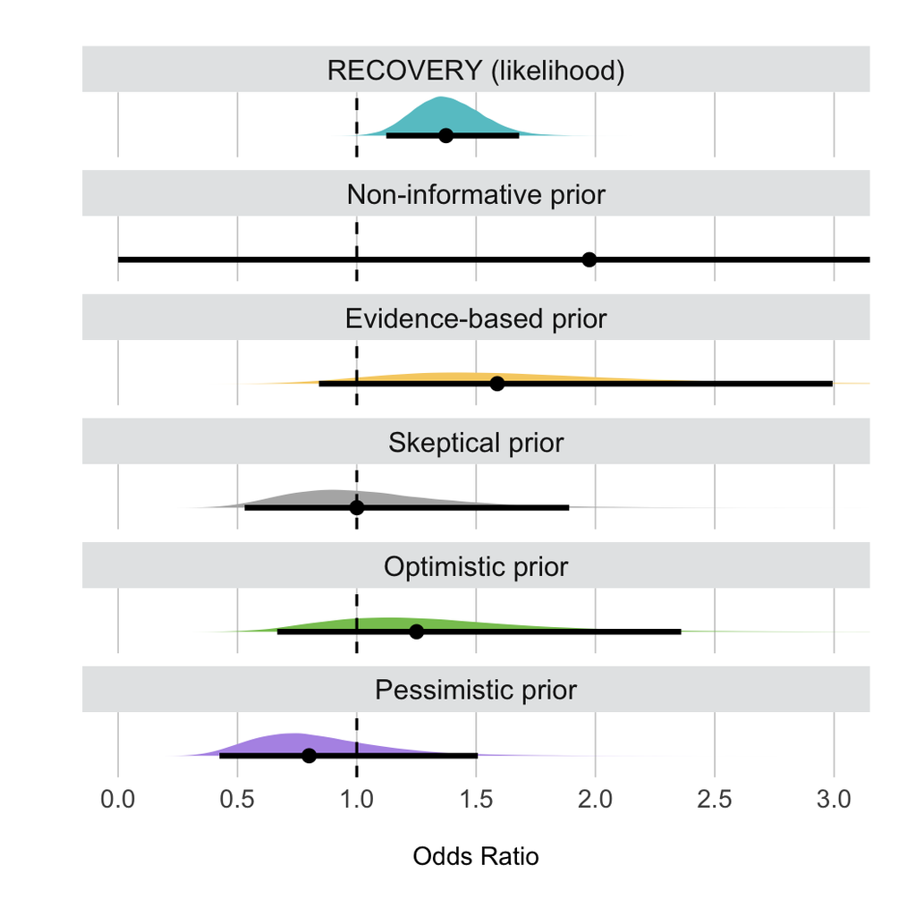

```r
# Plot!

distributions %>%
  # make it tidy for ggplot
  pivot_longer(
    cols = c(everything()),
    names_to = "dist", values_to = "samples"
  ) %>%
  # Set order of priors
  mutate(dist = factor(dist, levels =
                         c("RECOVERY (likelihood)",
                           "Non-informative prior",
                           "Evidence-based prior",
                           "Skeptical prior",
                           "Optimistic prior",
                           "Pessimistic prior")
  )
  ) %>%
  # exp() to transform log(OR) to OR
  ggplot(aes(
    x = exp(samples), y = dist,
    fill = dist
  )) +

  # https://mjskay.github.io/ggdist/articles/slabinterval.html
  stat_halfeye(position = "dodge",
               point_interval = median_qi, # Quantile interval
               .width = c(0.95)) +
  geom_vline(xintercept = 1, linetype = 2, size = 0.6) +
  scale_fill_manual(' ',
                    values = c(
                      carto_pal(12, "Pastel")[1], # RECOVERY
                      carto_pal(12, "Pastel")[12], # Non-informative,
                      carto_pal(12, "Pastel")[2], # Evidence-based
                      "gray70", # Skeptical
                      carto_pal(12, "Pastel")[5], # Optimistic
                      carto_pal(12, "Pastel")[10]  # Pessimistc
                    )) +
  labs(
    x = "\nOdds Ratio",
    y = " "
  ) +
  scale_x_continuous(breaks = seq(from = 0, to = 3, 0.5)) +
  scale_y_discrete(expand = c(0, 0.5)) +
  theme(
    strip.background = element_rect(fill = "#E4E6E7"),
    strip.text.x = element_text(size = 12),
    axis.ticks.x = element_blank(),
    axis.ticks.y = element_blank(),
    axis.text.x = element_text(size = 11),
    axis.text.y = element_blank(),
    panel.background = element_blank(),
    panel.grid.major.x = element_line(color = "gray80", size = 0.3),
    legend.position = 'none',
    legend.text = element_text(size=12),
    legend.key= element_blank(),
    plot.margin = margin(20, 20, 20, 20)
  ) +
  coord_cartesian(x = c(0, 3)) +
  facet_wrap(~dist, ncol = 1, scales = "free_y")
```

#### Posterior distributions

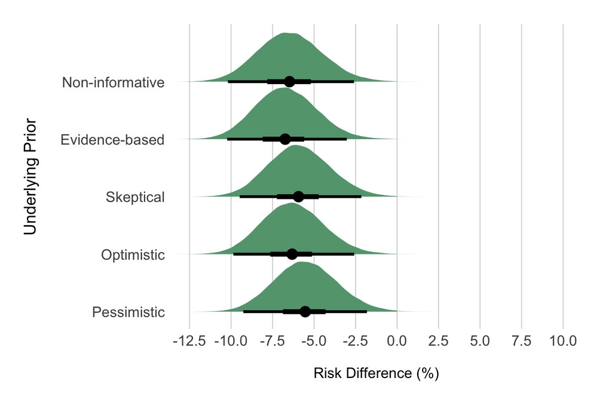

Point estimates depict the median. Interval bars depict the 50 and 95% highest density intervals.

```r
level_order = c("Pessimistic",
                "Optimistic",
                "Skeptical",
                "Evidence-based",
                "Non-informative")

samples_posteriors_simple_discharge %>%

  ggplot(aes(
    # Multiply by 100 to report in percentage
    x = 100 * RD,
    y = factor(`Underlying_Prior`, level = level_order),
    fill = `Underlying_Prior`)) +

  # https://mjskay.github.io/ggdist/articles/slabinterval.html
  stat_halfeye(aes(fill = stat(x < 0)),
               position = "dodge",
               point_interval = median_hdi, # Highest density interval
               .width = c(0.5, 0.95),
               # https://github.com/mjskay/ggdist/issues/70
               interval_size_range = c(1.1,1.9)
  ) +
  scale_fill_manual(values = c("gray85", "#64A37E")) +
  labs(x = "\nRisk Difference (%)",
       y = "Underlying Prior\n"
  ) +
  scale_x_continuous(breaks = seq(from = -12.5, to = 10, 2.5)) +
  scale_y_discrete(expand = c(0, 0.3)) +
  theme(axis.title.x = element_text(size = 12),
        axis.title.y = element_text(size = 13.5),
        axis.text.y = element_text(size = 12),
        axis.text.x = element_text(size = 12),
        axis.ticks.x = element_blank(),
        axis.ticks.y = element_blank(),
        panel.background = element_blank(),
        panel.grid.major.x = element_line(color = "gray80", size = 0.3),
        legend.position = "none",
        plot.title.position = 'plot',
        plot.margin = margin(20, 25, 10, 20)
  ) +
  coord_cartesian(xlim = c(-12.5, 10))
```

```r
# ggsave(width = 7,
#        height = 4.5,
#         here("final_analyses", "output", "plots", "appendix", # File path
#                   "SFigure18_discharge_posteriors_simple.pdf")) # File name
```

```r
t = tibble(

  "Underlying Prior" = c(
    "Non-informative",
    "Evidence-based",
    "Skeptical",
    "Optimistic",
    "Pessimistic"
  ),


  "Pr(< -5%)" = c(round((samples_posteriors_simple_discharge %>%
                           filter(`Underlying_Prior` == "Non-informative") %>%
                           summarise(n = sum(RD < -0.05) / n()) %>%
                           pull()), 2) * 100,

                  round((samples_posteriors_simple_discharge %>%
                           filter(`Underlying_Prior` == "Evidence-based") %>%
                           summarise(n = sum(RD < -0.05) / n()) %>%
                           pull()), 2) * 100,

                  round((samples_posteriors_simple_discharge %>%
                           filter(`Underlying_Prior` == "Skeptical") %>%
                           summarise(n = sum(RD < -0.05) / n()) %>%
                           pull()), 2) * 100,

                  round((samples_posteriors_simple_discharge %>%
                           filter(`Underlying_Prior` == "Optimistic") %>%
                           summarise(n = sum(RD < -0.05) / n()) %>%
                           pull()), 2) * 100,

                  round((samples_posteriors_simple_discharge %>%
                           filter(`Underlying_Prior` == "Pessimistic") %>%
                           summarise(n = sum(RD < -0.05) / n()) %>%
                           pull()), 2) * 100
  ),

  "Pr(< -2%)" = c(round((samples_posteriors_simple_discharge %>%
                           filter(`Underlying_Prior` == "Non-informative") %>%
                           summarise(n = sum(RD < -0.02) / n()) %>%
                           pull()), 2) * 100,

                  round((samples_posteriors_simple_discharge %>%
                           filter(`Underlying_Prior` == "Evidence-based") %>%
                           summarise(n = sum(RD < -0.02) / n()) %>%
                           pull()), 2) * 100,

                  round((samples_posteriors_simple_discharge %>%
                           filter(`Underlying_Prior` == "Skeptical") %>%
                           summarise(n = sum(RD < -0.02) / n()) %>%
                           pull()), 2) * 100,

                  round((samples_posteriors_simple_discharge %>%
                           filter(`Underlying_Prior` == "Optimistic") %>%
                           summarise(n = sum(RD < -0.02) / n()) %>%
                           pull()), 2) * 100,

                  round((samples_posteriors_simple_discharge %>%
                           filter(`Underlying_Prior` == "Pessimistic") %>%
                           summarise(n = sum(RD < -0.02) / n()) %>%
                           pull()), 2) * 100
  ),

  "Pr(< -1%)" = c(round((samples_posteriors_simple_discharge %>%
                           filter(`Underlying_Prior` == "Non-informative") %>%
                           summarise(n = sum(RD < -0.01) / n()) %>%
                           pull()), 2) * 100,

                  round((samples_posteriors_simple_discharge %>%
                           filter(`Underlying_Prior` == "Evidence-based") %>%
                           summarise(n = sum(RD < -0.01) / n()) %>%
                           pull()), 2) * 100,

                  round((samples_posteriors_simple_discharge %>%
                           filter(`Underlying_Prior` == "Skeptical") %>%
                           summarise(n = sum(RD < -0.01) / n()) %>%
                           pull()), 2) * 100,

                  round((samples_posteriors_simple_discharge %>%
                           filter(`Underlying_Prior` == "Optimistic") %>%
                           summarise(n = sum(RD < -0.01) / n()) %>%
                           pull()), 2) * 100,

                  round((samples_posteriors_simple_discharge %>%
                           filter(`Underlying_Prior` == "Pessimistic") %>%
                           summarise(n = sum(RD < -0.01) / n()) %>%
                           pull()), 2) * 100
  ),


  "Pr(< 0%)" = c(round((samples_posteriors_simple_discharge %>%
                          filter(`Underlying_Prior` == "Non-informative") %>%
                          summarise(n = sum(RD < 0) / n()) %>%
                          pull()), 2) * 100,

                 round((samples_posteriors_simple_discharge %>%
                          filter(`Underlying_Prior` == "Evidence-based") %>%
                          summarise(n = sum(RD < 0) / n()) %>%
                          pull()), 2) * 100,

                 round((samples_posteriors_simple_discharge %>%
                          filter(`Underlying_Prior` == "Skeptical") %>%
                          summarise(n = sum(RD < 0) / n()) %>%
                          pull()), 2) * 100,

                 round((samples_posteriors_simple_discharge %>%
                          filter(`Underlying_Prior` == "Optimistic") %>%
                          summarise(n = sum(RD < 0) / n()) %>%
                          pull()), 2) * 100,

                 round((samples_posteriors_simple_discharge %>%
                          filter(`Underlying_Prior` == "Pessimistic") %>%
                          summarise(n = sum(RD < 0) / n()) %>%
                          pull()), 2) * 100
  ),

  "Pr(> 1%)" = c(round((samples_posteriors_simple_discharge %>%
                          filter(`Underlying_Prior` == "Non-informative") %>%
                          summarise(n = sum(RD > 0.01) / n()) %>%
                          pull()), 2) * 100,

                 round((samples_posteriors_simple_discharge %>%
                          filter(`Underlying_Prior` == "Evidence-based") %>%
                          summarise(n = sum(RD > 0.01) / n()) %>%
                          pull()), 2) * 100,

                 round((samples_posteriors_simple_discharge %>%
                          filter(`Underlying_Prior` == "Skeptical") %>%
                          summarise(n = sum(RD > 0.01) / n()) %>%
                          pull()), 2) * 100,

                 round((samples_posteriors_simple_discharge %>%
                          filter(`Underlying_Prior` == "Optimistic") %>%
                          summarise(n = sum(RD > 0.01) / n()) %>%
                          pull()), 2) * 100,

                 round((samples_posteriors_simple_discharge %>%
                          filter(`Underlying_Prior` == "Pessimistic") %>%
                          summarise(n = sum(RD > 0.01) / n()) %>%
                          pull()), 2) * 100
  ),

  "Pr(> 2%)" = c(round((samples_posteriors_simple_discharge %>%
                          filter(`Underlying_Prior` == "Non-informative") %>%
                          summarise(n = sum(RD > 0.02) / n()) %>%
                          pull()), 2) * 100,

                 round((samples_posteriors_simple_discharge %>%
                          filter(`Underlying_Prior` == "Evidence-based") %>%
                          summarise(n = sum(RD > 0.02) / n()) %>%
                          pull()), 2) * 100,

                 round((samples_posteriors_simple_discharge %>%
                          filter(`Underlying_Prior` == "Skeptical") %>%
                          summarise(n = sum(RD > 0.02) / n()) %>%
                          pull()), 2) * 100,

                 round((samples_posteriors_simple_discharge %>%
                          filter(`Underlying_Prior` == "Optimistic") %>%
                          summarise(n = sum(RD > 0.02) / n()) %>%
                          pull()), 2) * 100,

                 round((samples_posteriors_simple_discharge %>%
                          filter(`Underlying_Prior` == "Pessimistic") %>%
                          summarise(n = sum(RD > 0.02) / n()) %>%
                          pull()), 2) * 100
  ),

  "Pr(> 5%)" = c(round((samples_posteriors_simple_discharge %>%
                          filter(`Underlying_Prior` == "Non-informative") %>%
                          summarise(n = sum(RD > 0.05) / n()) %>%
                          pull()), 2) * 100,

                 round((samples_posteriors_simple_discharge %>%
                          filter(`Underlying_Prior` == "Evidence-based") %>%
                          summarise(n = sum(RD > 0.05) / n()) %>%
                          pull()), 2) * 100,

                 round((samples_posteriors_simple_discharge %>%
                          filter(`Underlying_Prior` == "Skeptical") %>%
                          summarise(n = sum(RD > 0.05) / n()) %>%
                          pull()), 2) * 100,

                 round((samples_posteriors_simple_discharge %>%
                          filter(`Underlying_Prior` == "Optimistic") %>%
                          summarise(n = sum(RD > 0.05) / n()) %>%
                          pull()), 2) * 100,

                 round((samples_posteriors_simple_discharge %>%
                          filter(`Underlying_Prior` == "Pessimistic") %>%
                          summarise(n = sum(RD > 0.05) / n()) %>%
                          pull()), 2) * 100
  )
)

t1 = t %>%
  kbl(booktabs = T, align = 'c') %>%
  kable_styling(bootstrap_options = "striped", full_width = F) %>%
  add_header_above(c(" " = 1,
                     "Probability of Benefit" = 4,
                     "Probability of Harm" = 3))

t1
```

| Underlying Prior | Probability of Benefit Pr(< -5%) | Probability of Benefit Pr(< -2%) | Probability of Benefit Pr(< -1%) | Probability of Benefit Pr(< 0%) | Probability of Harm Pr(> 1%) | Probability of Harm Pr(> 2%) | Probability of Harm Pr(> 5%) |
| --- | --- | --- | --- | --- | --- | --- | --- |
| Non-informative | 77 | 99 | 100 | 100 | 0 | 0 | 0 |
| Evidence-based | 82 | 99 | 100 | 100 | 0 | 0 | 0 |
| Skeptical | 69 | 98 | 99 | 100 | 0 | 0 | 0 |
| Optimistic | 76 | 99 | 100 | 100 | 0 | 0 | 0 |
| Pessimistic | 61 | 96 | 99 | 100 | 0 | 0 | 0 |

```r
# t1 %>%
#   save_kable(here("final_analyses", "output", "plots", "appendix", # File path
#                   "STable16_discharge_probabilities_simple.pdf")) # File name
```

##### HDI for each posterior distribution

Here are the 95% HDI in *risk difference* of each distribution.

```r
multiply100 = function(x){x*100}

samples_posteriors_simple_discharge %>%
  select("Underlying_Prior", "RD") %>%
  # Group by distribution so we can apply median_hdi
  group_by(`Underlying_Prior`) %>%
  # Calculate the median and 95% quantile interval in log-odds ratio
  ggdist::median_hdi(.width = 0.95) %>%
  # Select only the relevant columns
  # Arrange order
  arrange(factor(`Underlying_Prior`, levels = c(
    "Non-informative",
    "Evidence-based",
    "Skeptical",
    "Optimistic",
    "Pessimistic"
    ))) %>%
  select("Underlying_Prior":.upper) %>%
  mutate(across(RD:.upper, ~multiply100(.))) %>%
  mutate(across(RD:.upper, ~round(., 2))) %>%
  rename("Underlying Prior" = Underlying_Prior,
         "Median" = RD,
         "Upper limit" = .upper,
         "Lower limit" = .lower) %>%
  kbl(booktabs = T, align = 'c') %>%
  kable_styling(bootstrap_options = "striped", full_width = F) %>%
  add_header_above(c(" " = 1,
                     "95% Highest Density Interval" = 3))
```

| Underlying Prior | 95% Highest Density Interval Median | 95% Highest Density Interval Lower limit | 95% Highest Density Interval Upper limit |
| --- | --- | --- | --- |
| Non-informative | -6.48 | -10.19 | -2.59 |
| Evidence-based | -6.74 | -10.23 | -3.03 |
| Skeptical | -5.93 | -9.48 | -2.15 |
| Optimistic | -6.32 | -9.86 | -2.58 |
| Pessimistic | -5.53 | -9.26 | -1.81 |

### Non-invasive ventilation

#### Prior and likelihood distributions

```r
distributions =
  tibble(

    "RECOVERY (likelihood)" = list(
      rnorm(
        10e4,
        mean = (posteriors_noninvasive_discharge %>%
                  # Data.mean and data.sd are all the same in every row
                  # So it doesn't matter what row I slice
                  slice(1) %>%
                  pull(data.mean)),
        sd = (posteriors_noninvasive_discharge %>%
                slice(1) %>%
                pull(data.sd))
      )),

    "Non-informative prior" = list(
      rnorm(
        10e4,
        mean = (posteriors_noninvasive_discharge %>%
                  filter(type == "non-informative") %>%
                  pull(prior.mean)),
        sd = (posteriors_noninvasive_discharge %>%
                filter(type == "non-informative") %>%
                pull(prior.sd))
      )),

    "Evidence-based prior" = list(
      rnorm(
        10e4,
        mean = (posteriors_noninvasive_discharge %>%
                  filter(type == "evidence-based") %>%
                  pull(prior.mean)),
        sd = (posteriors_noninvasive_discharge %>%
                filter(type == "evidence-based") %>%
                pull(prior.sd))
      )),

    "Skeptical prior" = list(
      rnorm(
        10e4,
        mean = (posteriors_noninvasive_discharge %>%
                  filter(type == "skeptical") %>%
                  pull(prior.mean)),
        sd = (posteriors_noninvasive_discharge %>%
                filter(type == "skeptical") %>%
                pull(prior.sd))
      )),

    "Optimistic prior" = list(
      rnorm(
        10e4,
        mean = (posteriors_noninvasive_discharge %>%
                  filter(type == "optimistic") %>%
                  pull(prior.mean)),
        sd = (posteriors_noninvasive_discharge %>%
                filter(type == "optimistic") %>%
                pull(prior.sd))
      )),

    "Pessimistic prior" = list(
      rnorm(
        10e4,
        mean = (posteriors_noninvasive_discharge %>%
                  filter(type == "pessimistic") %>%
                  pull(prior.mean)),
        sd = (posteriors_noninvasive_discharge %>%
                filter(type == "pessimistic") %>%
                pull(prior.sd))
      ))
  ) %>%
  unnest(everything())
```

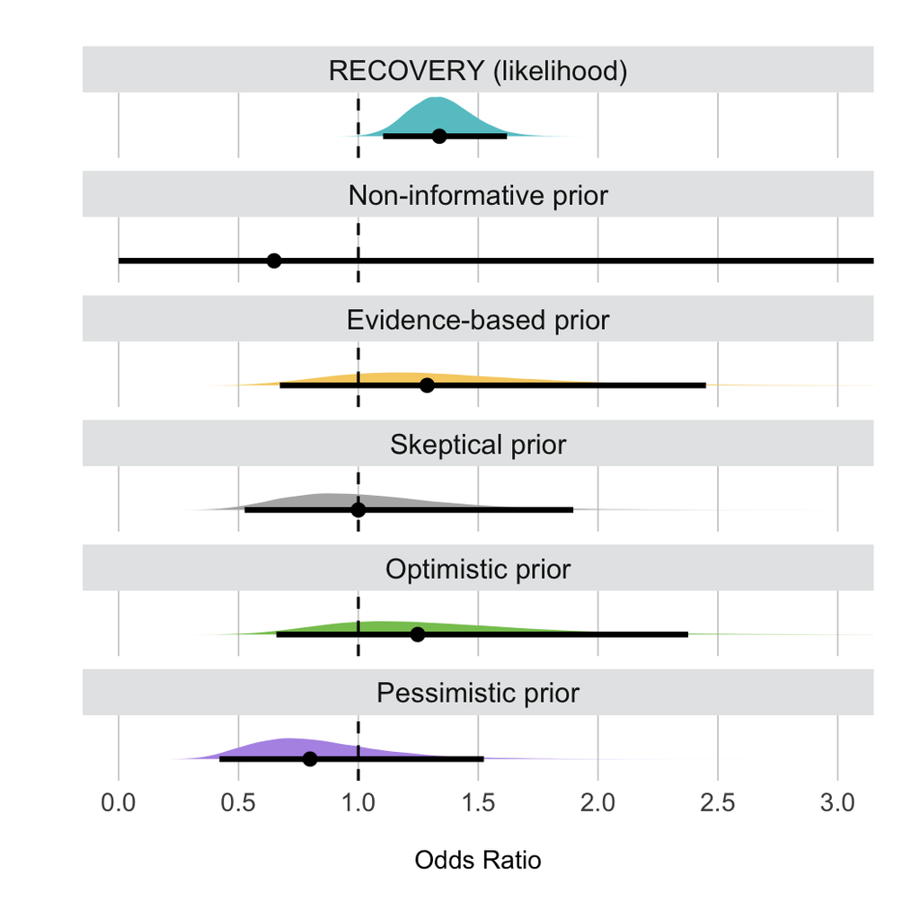

```r
# Plot!

distributions %>%
  # make it tidy for ggplot
  pivot_longer(
    cols = c(everything()),
    names_to = "dist", values_to = "samples"
  ) %>%
  # Set order of priors
  mutate(dist = factor(dist, levels =
                         c("RECOVERY (likelihood)",
                           "Non-informative prior",
                           "Evidence-based prior",
                           "Skeptical prior",
                           "Optimistic prior",
                           "Pessimistic prior")
  )
  ) %>%
  # exp() to transform log(OR) to OR
  ggplot(aes(
    x = exp(samples), y = dist,
    fill = dist
  )) +

  # https://mjskay.github.io/ggdist/articles/slabinterval.html
  stat_halfeye(position = "dodge",
               point_interval = median_qi, # Quantile interval
               .width = c(0.95)) +
  geom_vline(xintercept = 1, linetype = 2, size = 0.6) +
  scale_fill_manual(' ',
                    values = c(
                      carto_pal(12, "Pastel")[1], # RECOVERY
                      carto_pal(12, "Pastel")[12], # Non-informative,
                      carto_pal(12, "Pastel")[2], # Evidence-based
                      "gray70", # Skeptical
                      carto_pal(12, "Pastel")[5], # Optimistic
                      carto_pal(12, "Pastel")[10]  # Pessimistc
                    )) +
  labs(
    x = "\nOdds Ratio",
    y = " "
  ) +
  scale_x_continuous(breaks = seq(from = 0, to = 3, 0.5)) +
  scale_y_discrete(expand = c(0, 0.5)) +
  theme(
    strip.background = element_rect(fill = "#E4E6E7"),
    strip.text.x = element_text(size = 12),
    axis.ticks.x = element_blank(),
    axis.ticks.y = element_blank(),
    axis.text.x = element_text(size = 11),
    axis.text.y = element_blank(),
    panel.background = element_blank(),
    panel.grid.major.x = element_line(color = "gray80", size = 0.3),
    legend.position = 'none',
    legend.text = element_text(size=12),
    legend.key= element_blank(),
    plot.margin = margin(20, 20, 20, 20)
  ) +
  coord_cartesian(x = c(0, 3)) +
  facet_wrap(~dist, ncol = 1, scales = "free_y")
```

#### Posterior distributions

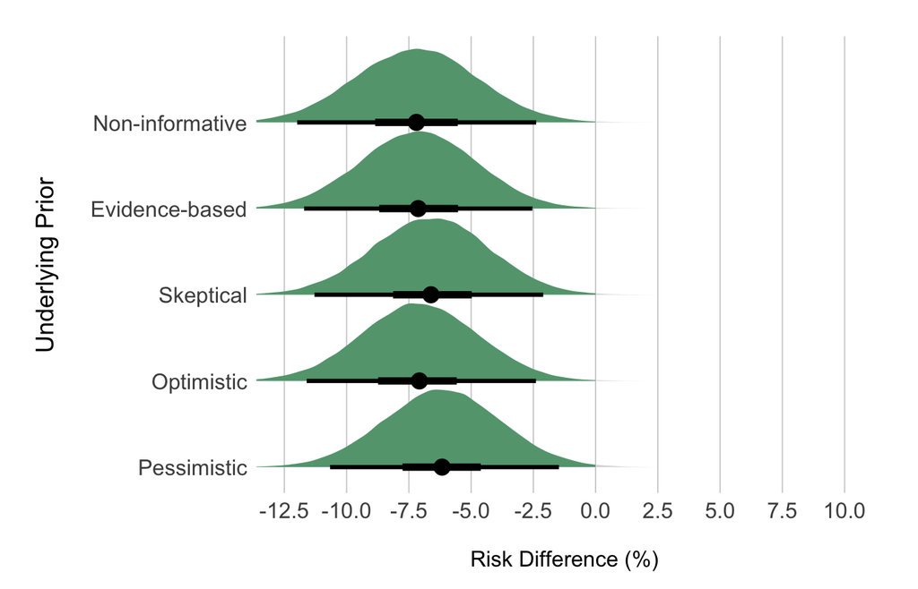

Point estimates depict the median. Interval bars depict the 50 and 95% highest density intervals.

```r
level_order = c("Pessimistic",
                "Optimistic",
                "Skeptical",
                "Evidence-based",
                "Non-informative")

samples_posteriors_noninvasive_discharge %>%

  ggplot(aes(
    # Multiply by 100 to report in percentage
    x = 100 * RD,
    y = factor(`Underlying_Prior`, level = level_order),
    fill = `Underlying_Prior`)) +

  # https://mjskay.github.io/ggdist/articles/slabinterval.html
  stat_halfeye(aes(fill = stat(x < 0)),
               position = "dodge",
               point_interval = median_hdi, # Highest density interval
               .width = c(0.5, 0.95),
               # https://github.com/mjskay/ggdist/issues/70
               interval_size_range = c(1.1,1.9)
  ) +
  scale_fill_manual(values = c("gray85", "#64A37E")) +
  labs(x = "\nRisk Difference (%)",
       y = "Underlying Prior\n"
  ) +
  scale_x_continuous(breaks = seq(from = -12.5, to = 10, 2.5)) +
  scale_y_discrete(expand = c(0, 0.3)) +
  theme(axis.title.x = element_text(size = 12),
        axis.title.y = element_text(size = 13.5),
        axis.text.y = element_text(size = 12),
        axis.text.x = element_text(size = 12),
        axis.ticks.x = element_blank(),
        axis.ticks.y = element_blank(),
        panel.background = element_blank(),
        panel.grid.major.x = element_line(color = "gray80", size = 0.3),
        legend.position = "none",
        plot.title.position = 'plot',
        plot.margin = margin(20, 25, 10, 20)
  ) +
  coord_cartesian(xlim = c(-12.5, 10))
```

```r
# ggsave(width = 7,
#        height = 4.5,
#         here("final_analyses", "output", "plots", "appendix", # File path
#                   "SFigure19_discharge_posteriors_noninvasive.pdf")) # File name
```

```r
t = tibble(

  "Underlying Prior" = c(
    "Non-informative",
    "Evidence-based",
    "Skeptical",
    "Optimistic",
    "Pessimistic"
  ),


  "Pr(< -5%)" = c(round((samples_posteriors_noninvasive_discharge %>%
                           filter(`Underlying_Prior` == "Non-informative") %>%
                           summarise(n = sum(RD < -0.05) / n()) %>%
                           pull()), 2) * 100,

                  round((samples_posteriors_noninvasive_discharge %>%
                           filter(`Underlying_Prior` == "Evidence-based") %>%
                           summarise(n = sum(RD < -0.05) / n()) %>%
                           pull()), 2) * 100,

                  round((samples_posteriors_noninvasive_discharge %>%
                           filter(`Underlying_Prior` == "Skeptical") %>%
                           summarise(n = sum(RD < -0.05) / n()) %>%
                           pull()), 2) * 100,

                  round((samples_posteriors_noninvasive_discharge %>%
                           filter(`Underlying_Prior` == "Optimistic") %>%
                           summarise(n = sum(RD < -0.05) / n()) %>%
                           pull()), 2) * 100,

                  round((samples_posteriors_noninvasive_discharge %>%
                           filter(`Underlying_Prior` == "Pessimistic") %>%
                           summarise(n = sum(RD < -0.05) / n()) %>%
                           pull()), 2) * 100
  ),

  "Pr(< -2%)" = c(round((samples_posteriors_noninvasive_discharge %>%
                           filter(`Underlying_Prior` == "Non-informative") %>%
                           summarise(n = sum(RD < -0.02) / n()) %>%
                           pull()), 2) * 100,

                  round((samples_posteriors_noninvasive_discharge %>%
                           filter(`Underlying_Prior` == "Evidence-based") %>%
                           summarise(n = sum(RD < -0.02) / n()) %>%
                           pull()), 2) * 100,

                  round((samples_posteriors_noninvasive_discharge %>%
                           filter(`Underlying_Prior` == "Skeptical") %>%
                           summarise(n = sum(RD < -0.02) / n()) %>%
                           pull()), 2) * 100,

                  round((samples_posteriors_noninvasive_discharge %>%
                           filter(`Underlying_Prior` == "Optimistic") %>%
                           summarise(n = sum(RD < -0.02) / n()) %>%
                           pull()), 2) * 100,

                  round((samples_posteriors_noninvasive_discharge %>%
                           filter(`Underlying_Prior` == "Pessimistic") %>%
                           summarise(n = sum(RD < -0.02) / n()) %>%
                           pull()), 2) * 100
  ),

  "Pr(< -1%)" = c(round((samples_posteriors_noninvasive_discharge %>%
                           filter(`Underlying_Prior` == "Non-informative") %>%
                           summarise(n = sum(RD < -0.01) / n()) %>%
                           pull()), 2) * 100,

                  round((samples_posteriors_noninvasive_discharge %>%
                           filter(`Underlying_Prior` == "Evidence-based") %>%
                           summarise(n = sum(RD < -0.01) / n()) %>%
                           pull()), 2) * 100,

                  round((samples_posteriors_noninvasive_discharge %>%
                           filter(`Underlying_Prior` == "Skeptical") %>%
                           summarise(n = sum(RD < -0.01) / n()) %>%
                           pull()), 2) * 100,

                  round((samples_posteriors_noninvasive_discharge %>%
                           filter(`Underlying_Prior` == "Optimistic") %>%
                           summarise(n = sum(RD < -0.01) / n()) %>%
                           pull()), 2) * 100,

                  round((samples_posteriors_noninvasive_discharge %>%
                           filter(`Underlying_Prior` == "Pessimistic") %>%
                           summarise(n = sum(RD < -0.01) / n()) %>%
                           pull()), 2) * 100
  ),


  "Pr(< 0%)" = c(round((samples_posteriors_noninvasive_discharge %>%
                          filter(`Underlying_Prior` == "Non-informative") %>%
                          summarise(n = sum(RD < 0) / n()) %>%
                          pull()), 2) * 100,

                 round((samples_posteriors_noninvasive_discharge %>%
                          filter(`Underlying_Prior` == "Evidence-based") %>%
                          summarise(n = sum(RD < 0) / n()) %>%
                          pull()), 2) * 100,

                 round((samples_posteriors_noninvasive_discharge %>%
                          filter(`Underlying_Prior` == "Skeptical") %>%
                          summarise(n = sum(RD < 0) / n()) %>%
                          pull()), 2) * 100,

                 round((samples_posteriors_noninvasive_discharge %>%
                          filter(`Underlying_Prior` == "Optimistic") %>%
                          summarise(n = sum(RD < 0) / n()) %>%
                          pull()), 2) * 100,

                 round((samples_posteriors_noninvasive_discharge %>%
                          filter(`Underlying_Prior` == "Pessimistic") %>%
                          summarise(n = sum(RD < 0) / n()) %>%
                          pull()), 2) * 100
  ),

  "Pr(> 1%)" = c(round((samples_posteriors_noninvasive_discharge %>%
                          filter(`Underlying_Prior` == "Non-informative") %>%
                          summarise(n = sum(RD > 0.01) / n()) %>%
                          pull()), 2) * 100,

                 round((samples_posteriors_noninvasive_discharge %>%
                          filter(`Underlying_Prior` == "Evidence-based") %>%
                          summarise(n = sum(RD > 0.01) / n()) %>%
                          pull()), 2) * 100,

                 round((samples_posteriors_noninvasive_discharge %>%
                          filter(`Underlying_Prior` == "Skeptical") %>%
                          summarise(n = sum(RD > 0.01) / n()) %>%
                          pull()), 2) * 100,

                 round((samples_posteriors_noninvasive_discharge %>%
                          filter(`Underlying_Prior` == "Optimistic") %>%
                          summarise(n = sum(RD > 0.01) / n()) %>%
                          pull()), 2) * 100,

                 round((samples_posteriors_noninvasive_discharge %>%
                          filter(`Underlying_Prior` == "Pessimistic") %>%
                          summarise(n = sum(RD > 0.01) / n()) %>%
                          pull()), 2) * 100
  ),

  "Pr(> 2%)" = c(round((samples_posteriors_noninvasive_discharge %>%
                          filter(`Underlying_Prior` == "Non-informative") %>%
                          summarise(n = sum(RD > 0.02) / n()) %>%
                          pull()), 2) * 100,

                 round((samples_posteriors_noninvasive_discharge %>%
                          filter(`Underlying_Prior` == "Evidence-based") %>%
                          summarise(n = sum(RD > 0.02) / n()) %>%
                          pull()), 2) * 100,

                 round((samples_posteriors_noninvasive_discharge %>%
                          filter(`Underlying_Prior` == "Skeptical") %>%
                          summarise(n = sum(RD > 0.02) / n()) %>%
                          pull()), 2) * 100,

                 round((samples_posteriors_noninvasive_discharge %>%
                          filter(`Underlying_Prior` == "Optimistic") %>%
                          summarise(n = sum(RD > 0.02) / n()) %>%
                          pull()), 2) * 100,

                 round((samples_posteriors_noninvasive_discharge %>%
                          filter(`Underlying_Prior` == "Pessimistic") %>%
                          summarise(n = sum(RD > 0.02) / n()) %>%
                          pull()), 2) * 100
  ),

  "Pr(> 5%)" = c(round((samples_posteriors_noninvasive_discharge %>%
                          filter(`Underlying_Prior` == "Non-informative") %>%
                          summarise(n = sum(RD > 0.05) / n()) %>%
                          pull()), 2) * 100,

                 round((samples_posteriors_noninvasive_discharge %>%
                          filter(`Underlying_Prior` == "Evidence-based") %>%
                          summarise(n = sum(RD > 0.05) / n()) %>%
                          pull()), 2) * 100,

                 round((samples_posteriors_noninvasive_discharge %>%
                          filter(`Underlying_Prior` == "Skeptical") %>%
                          summarise(n = sum(RD > 0.05) / n()) %>%
                          pull()), 2) * 100,

                 round((samples_posteriors_noninvasive_discharge %>%
                          filter(`Underlying_Prior` == "Optimistic") %>%
                          summarise(n = sum(RD > 0.05) / n()) %>%
                          pull()), 2) * 100,

                 round((samples_posteriors_noninvasive_discharge %>%
                          filter(`Underlying_Prior` == "Pessimistic") %>%
                          summarise(n = sum(RD > 0.05) / n()) %>%
                          pull()), 2) * 100
  )
)

t1 = t %>%
  kbl(booktabs = T, align = 'c') %>%
  kable_styling(bootstrap_options = "striped", full_width = F) %>%
  add_header_above(c(" " = 1,
                     "Probability of Benefit" = 4,
                     "Probability of Harm" = 3))

t1
```

| Underlying Prior | Probability of Benefit Pr(< -5%) | Probability of Benefit Pr(< -2%) | Probability of Benefit Pr(< -1%) | Probability of Benefit Pr(< 0%) | Probability of Harm Pr(> 1%) | Probability of Harm Pr(> 2%) | Probability of Harm Pr(> 5%) |
| --- | --- | --- | --- | --- | --- | --- | --- |
| Non-informative | 82 | 98 | 99 | 100 | 0 | 0 | 0 |
| Evidence-based | 82 | 99 | 100 | 100 | 0 | 0 | 0 |
| Skeptical | 76 | 98 | 99 | 100 | 0 | 0 | 0 |
| Optimistic | 81 | 99 | 100 | 100 | 0 | 0 | 0 |
| Pessimistic | 69 | 96 | 99 | 100 | 0 | 0 | 0 |

```r
# t1 %>%
#   save_kable(here("final_analyses", "output", "plots", "appendix", # File path
#                   "STable17_discharge_probabilities_noninvasive.pdf")) # File name
```

##### HDI for each posterior distribution

Here are the 95% HDI in *risk difference* of each distribution.

```r
multiply100 = function(x){x*100}

samples_posteriors_noninvasive_discharge %>%
  select("Underlying_Prior", "RD") %>%
  # Group by distribution so we can apply median_hdi
  group_by(`Underlying_Prior`) %>%
  # Calculate the median and 95% quantile interval in log-odds ratio
  ggdist::median_hdi(.width = 0.95) %>%
  # Select only the relevant columns
  # Arrange order
  arrange(factor(`Underlying_Prior`, levels = c(
    "Non-informative",
    "Evidence-based",
    "Skeptical",
    "Optimistic",
    "Pessimistic"
    ))) %>%
  select("Underlying_Prior":.upper) %>%
  mutate(across(RD:.upper, ~multiply100(.))) %>%
  mutate(across(RD:.upper, ~round(., 2))) %>%
  rename("Underlying Prior" = Underlying_Prior,
         "Median" = RD,
         "Upper limit" = .upper,
         "Lower limit" = .lower) %>%
  kbl(booktabs = T, align = 'c') %>%
  kable_styling(bootstrap_options = "striped", full_width = F) %>%
  add_header_above(c(" " = 1,
                     "95% Highest Density Interval" = 3))
```

| Underlying Prior | 95% Highest Density Interval Median | 95% Highest Density Interval Lower limit | 95% Highest Density Interval Upper limit |
| --- | --- | --- | --- |
| Non-informative | -7.20 | -11.98 | -2.38 |
| Evidence-based | -7.13 | -11.71 | -2.54 |
| Skeptical | -6.61 | -11.29 | -2.10 |
| Optimistic | -7.08 | -11.60 | -2.40 |
| Pessimistic | -6.17 | -10.66 | -1.47 |

### Invasive mechanical ventilation

#### Prior and likelihood distributions

```r
distributions =
  tibble(

    "RECOVERY (likelihood)" = list(
      rnorm(
        10e4,
        mean = (posteriors_invasive_discharge %>%
                  # Data.mean and data.sd are all the same in every row
                  # So it doesn't matter what row I slice
                  slice(1) %>%
                  pull(data.mean)),
        sd = (posteriors_invasive_discharge %>%
                slice(1) %>%
                pull(data.sd))
      )),

    "Non-informative prior" = list(
      rnorm(
        10e4,
        mean = (posteriors_invasive_discharge %>%
                  filter(type == "non-informative") %>%
                  pull(prior.mean)),
        sd = (posteriors_invasive_discharge %>%
                filter(type == "non-informative") %>%
                pull(prior.sd))
      )),

    "Evidence-based prior" = list(
      rnorm(
        10e4,
        mean = (posteriors_invasive_discharge %>%
                  filter(type == "evidence-based") %>%
                  pull(prior.mean)),
        sd = (posteriors_invasive_discharge %>%
                filter(type == "evidence-based") %>%
                pull(prior.sd))
      )),

    "Skeptical prior" = list(
      rnorm(
        10e4,
        mean = (posteriors_invasive_discharge %>%
                  filter(type == "skeptical") %>%
                  pull(prior.mean)),
        sd = (posteriors_invasive_discharge %>%
                filter(type == "skeptical") %>%
                pull(prior.sd))
      )),

    "Optimistic prior" = list(
      rnorm(
        10e4,
        mean = (posteriors_invasive_discharge %>%
                  filter(type == "optimistic") %>%
                  pull(prior.mean)),
        sd = (posteriors_invasive_discharge %>%
                filter(type == "optimistic") %>%
                pull(prior.sd))
      )),

    "Pessimistic prior" = list(
      rnorm(
        10e4,
        mean = (posteriors_invasive_discharge %>%
                  filter(type == "pessimistic") %>%
                  pull(prior.mean)),
        sd = (posteriors_invasive_discharge %>%
                filter(type == "pessimistic") %>%
                pull(prior.sd))
      ))
  ) %>%
  unnest(everything())
```

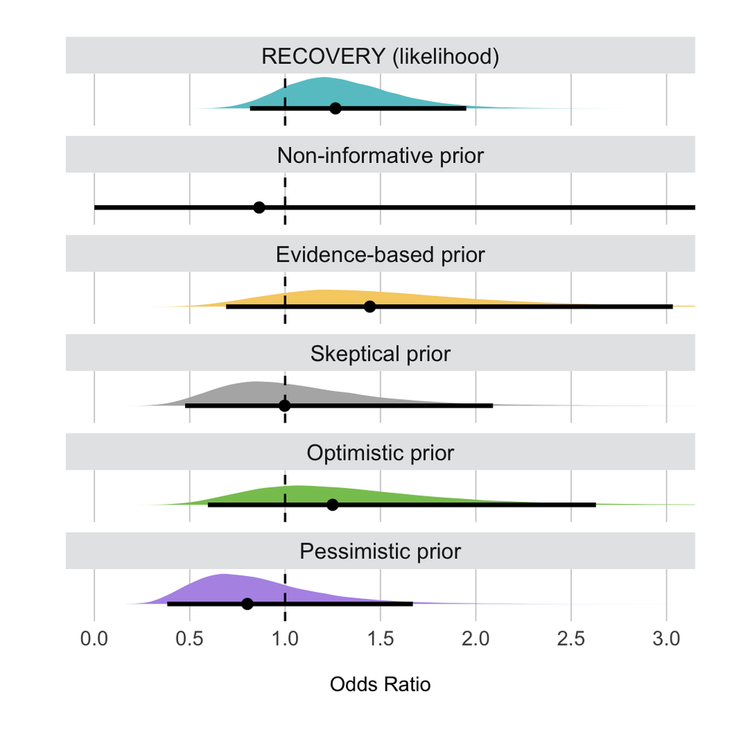

```r
# Plot!

distributions %>%
  # make it tidy for ggplot
  pivot_longer(
    cols = c(everything()),
    names_to = "dist", values_to = "samples"
  ) %>%
  # Set order of priors
  mutate(dist = factor(dist, levels =
                         c("RECOVERY (likelihood)",
                           "Non-informative prior",
                           "Evidence-based prior",
                           "Skeptical prior",
                           "Optimistic prior",
                           "Pessimistic prior")
  )
  ) %>%
  # exp() to transform log(OR) to OR
  ggplot(aes(
    x = exp(samples), y = dist,
    fill = dist
  )) +

  # https://mjskay.github.io/ggdist/articles/slabinterval.html
  stat_halfeye(position = "dodge",
               point_interval = median_qi, # Quantile interval
               .width = c(0.95)) +
  geom_vline(xintercept = 1, linetype = 2, size = 0.6) +
  scale_fill_manual(' ',
                    values = c(
                      carto_pal(12, "Pastel")[1], # RECOVERY
                      carto_pal(12, "Pastel")[12], # Non-informative,
                      carto_pal(12, "Pastel")[2], # Evidence-based
                      "gray70", # Skeptical
                      carto_pal(12, "Pastel")[5], # Optimistic
                      carto_pal(12, "Pastel")[10]  # Pessimistc
                    )) +
  labs(
    x = "\nOdds Ratio",
    y = " "
  ) +
  scale_x_continuous(breaks = seq(from = 0, to = 3, 0.5)) +
  scale_y_discrete(expand = c(0, 0.5)) +
  theme(
    strip.background = element_rect(fill = "#E4E6E7"),
    strip.text.x = element_text(size = 12),
    axis.ticks.x = element_blank(),
    axis.ticks.y = element_blank(),
    axis.text.x = element_text(size = 11),
    axis.text.y = element_blank(),
    panel.background = element_blank(),
    panel.grid.major.x = element_line(color = "gray80", size = 0.3),
    legend.position = 'none',
    legend.text = element_text(size=12),
    legend.key= element_blank(),
    plot.margin = margin(20, 20, 20, 20)
  ) +
  coord_cartesian(x = c(0, 3)) +
  facet_wrap(~dist, ncol = 1, scales = "free_y")
```

#### Posterior distributions

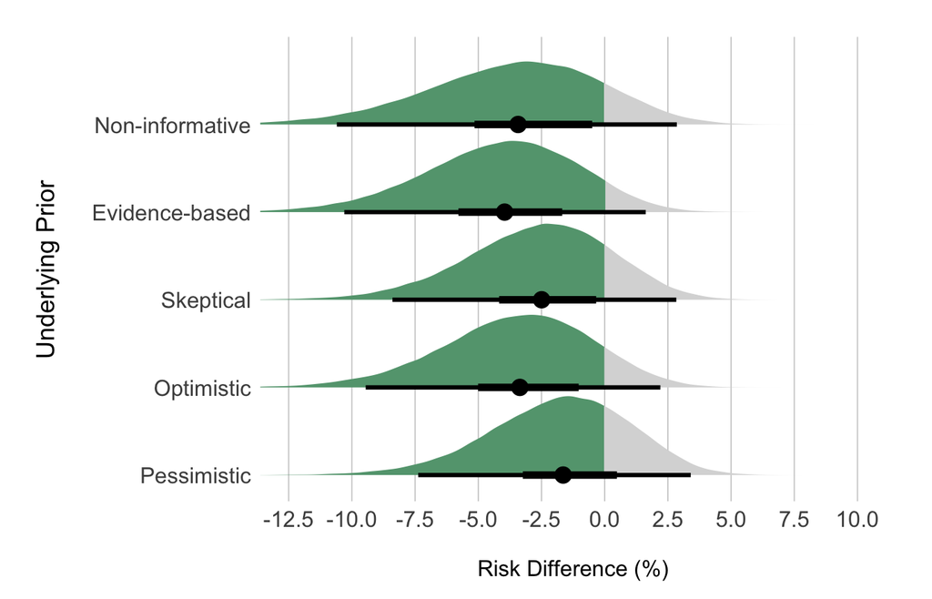

Point estimates depict the median. Interval bars depict the 50 and 95% highest density intervals.

```r
level_order = c("Pessimistic",
                "Optimistic",
                "Skeptical",
                "Evidence-based",
                "Non-informative")

samples_posteriors_invasive_discharge %>%

  ggplot(aes(
    # Multiply by 100 to report in percentage
    x = 100 * RD,
    y = factor(`Underlying_Prior`, level = level_order),
    fill = `Underlying_Prior`)) +

  # https://mjskay.github.io/ggdist/articles/slabinterval.html
  stat_halfeye(aes(fill = stat(x < 0)),
               position = "dodge",
               point_interval = median_hdi, # Highest density interval
               .width = c(0.5, 0.95),
               # https://github.com/mjskay/ggdist/issues/70
               interval_size_range = c(1.1,1.9)
  ) +
  scale_fill_manual(values = c("gray85", "#64A37E")) +
  labs(x = "\nRisk Difference (%)",
       y = "Underlying Prior\n"
  ) +
  scale_x_continuous(breaks = seq(from = -12.5, to = 10, 2.5)) +
  scale_y_discrete(expand = c(0, 0.3)) +
  theme(axis.title.x = element_text(size = 12),
        axis.title.y = element_text(size = 13.5),
        axis.text.y = element_text(size = 12),
        axis.text.x = element_text(size = 12),
        axis.ticks.x = element_blank(),
        axis.ticks.y = element_blank(),
        panel.background = element_blank(),
        panel.grid.major.x = element_line(color = "gray80", size = 0.3),
        legend.position = "none",
        plot.title.position = 'plot',
        plot.margin = margin(20, 25, 10, 20)
  ) +
  coord_cartesian(xlim = c(-12.5, 10))
```

```r
# ggsave(width = 7,
#        height = 4.5,
#         here("final_analyses", "output", "plots", "appendix", # File path
#                   "SFigure20_discharge_posteriors_invasive.pdf")) # File name
```

```r
t = tibble(

  "Underlying Prior" = c(
    "Non-informative",
    "Evidence-based",
    "Skeptical",
    "Optimistic",
    "Pessimistic"
  ),


  "Pr(< -5%)" = c(round((samples_posteriors_invasive_discharge %>%
                           filter(`Underlying_Prior` == "Non-informative") %>%
                           summarise(n = sum(RD < -0.05) / n()) %>%
                           pull()), 2) * 100,

                  round((samples_posteriors_invasive_discharge %>%
                           filter(`Underlying_Prior` == "Evidence-based") %>%
                           summarise(n = sum(RD < -0.05) / n()) %>%
                           pull()), 2) * 100,

                  round((samples_posteriors_invasive_discharge %>%
                           filter(`Underlying_Prior` == "Skeptical") %>%
                           summarise(n = sum(RD < -0.05) / n()) %>%
                           pull()), 2) * 100,

                  round((samples_posteriors_invasive_discharge %>%
                           filter(`Underlying_Prior` == "Optimistic") %>%
                           summarise(n = sum(RD < -0.05) / n()) %>%
                           pull()), 2) * 100,

                  round((samples_posteriors_invasive_discharge %>%
                           filter(`Underlying_Prior` == "Pessimistic") %>%
                           summarise(n = sum(RD < -0.05) / n()) %>%
                           pull()), 2) * 100
  ),

  "Pr(< -2%)" = c(round((samples_posteriors_invasive_discharge %>%
                           filter(`Underlying_Prior` == "Non-informative") %>%
                           summarise(n = sum(RD < -0.02) / n()) %>%
                           pull()), 2) * 100,

                  round((samples_posteriors_invasive_discharge %>%
                           filter(`Underlying_Prior` == "Evidence-based") %>%
                           summarise(n = sum(RD < -0.02) / n()) %>%
                           pull()), 2) * 100,

                  round((samples_posteriors_invasive_discharge %>%
                           filter(`Underlying_Prior` == "Skeptical") %>%
                           summarise(n = sum(RD < -0.02) / n()) %>%
                           pull()), 2) * 100,

                  round((samples_posteriors_invasive_discharge %>%
                           filter(`Underlying_Prior` == "Optimistic") %>%
                           summarise(n = sum(RD < -0.02) / n()) %>%
                           pull()), 2) * 100,

                  round((samples_posteriors_invasive_discharge %>%
                           filter(`Underlying_Prior` == "Pessimistic") %>%
                           summarise(n = sum(RD < -0.02) / n()) %>%
                           pull()), 2) * 100
  ),

  "Pr(< -1%)" = c(round((samples_posteriors_invasive_discharge %>%
                           filter(`Underlying_Prior` == "Non-informative") %>%
                           summarise(n = sum(RD < -0.01) / n()) %>%
                           pull()), 2) * 100,

                  round((samples_posteriors_invasive_discharge %>%
                           filter(`Underlying_Prior` == "Evidence-based") %>%
                           summarise(n = sum(RD < -0.01) / n()) %>%
                           pull()), 2) * 100,

                  round((samples_posteriors_invasive_discharge %>%
                           filter(`Underlying_Prior` == "Skeptical") %>%
                           summarise(n = sum(RD < -0.01) / n()) %>%
                           pull()), 2) * 100,

                  round((samples_posteriors_invasive_discharge %>%
                           filter(`Underlying_Prior` == "Optimistic") %>%
                           summarise(n = sum(RD < -0.01) / n()) %>%
                           pull()), 2) * 100,

                  round((samples_posteriors_invasive_discharge %>%
                           filter(`Underlying_Prior` == "Pessimistic") %>%
                           summarise(n = sum(RD < -0.01) / n()) %>%
                           pull()), 2) * 100
  ),


  "Pr(< 0%)" = c(round((samples_posteriors_invasive_discharge %>%
                          filter(`Underlying_Prior` == "Non-informative") %>%
                          summarise(n = sum(RD < 0) / n()) %>%
                          pull()), 2) * 100,

                 round((samples_posteriors_invasive_discharge %>%
                          filter(`Underlying_Prior` == "Evidence-based") %>%
                          summarise(n = sum(RD < 0) / n()) %>%
                          pull()), 2) * 100,

                 round((samples_posteriors_invasive_discharge %>%
                          filter(`Underlying_Prior` == "Skeptical") %>%
                          summarise(n = sum(RD < 0) / n()) %>%
                          pull()), 2) * 100,

                 round((samples_posteriors_invasive_discharge %>%
                          filter(`Underlying_Prior` == "Optimistic") %>%
                          summarise(n = sum(RD < 0) / n()) %>%
                          pull()), 2) * 100,

                 round((samples_posteriors_invasive_discharge %>%
                          filter(`Underlying_Prior` == "Pessimistic") %>%
                          summarise(n = sum(RD < 0) / n()) %>%
                          pull()), 2) * 100
  ),

  "Pr(> 1%)" = c(round((samples_posteriors_invasive_discharge %>%
                          filter(`Underlying_Prior` == "Non-informative") %>%
                          summarise(n = sum(RD > 0.01) / n()) %>%
                          pull()), 2) * 100,

                 round((samples_posteriors_invasive_discharge %>%
                          filter(`Underlying_Prior` == "Evidence-based") %>%
                          summarise(n = sum(RD > 0.01) / n()) %>%
                          pull()), 2) * 100,

                 round((samples_posteriors_invasive_discharge %>%
                          filter(`Underlying_Prior` == "Skeptical") %>%
                          summarise(n = sum(RD > 0.01) / n()) %>%
                          pull()), 2) * 100,

                 round((samples_posteriors_invasive_discharge %>%
                          filter(`Underlying_Prior` == "Optimistic") %>%
                          summarise(n = sum(RD > 0.01) / n()) %>%
                          pull()), 2) * 100,

                 round((samples_posteriors_invasive_discharge %>%
                          filter(`Underlying_Prior` == "Pessimistic") %>%
                          summarise(n = sum(RD > 0.01) / n()) %>%
                          pull()), 2) * 100
  ),

  "Pr(> 2%)" = c(round((samples_posteriors_invasive_discharge %>%
                          filter(`Underlying_Prior` == "Non-informative") %>%
                          summarise(n = sum(RD > 0.02) / n()) %>%
                          pull()), 2) * 100,

                 round((samples_posteriors_invasive_discharge %>%
                          filter(`Underlying_Prior` == "Evidence-based") %>%
                          summarise(n = sum(RD > 0.02) / n()) %>%
                          pull()), 2) * 100,

                 round((samples_posteriors_invasive_discharge %>%
                          filter(`Underlying_Prior` == "Skeptical") %>%
                          summarise(n = sum(RD > 0.02) / n()) %>%
                          pull()), 2) * 100,

                 round((samples_posteriors_invasive_discharge %>%
                          filter(`Underlying_Prior` == "Optimistic") %>%
                          summarise(n = sum(RD > 0.02) / n()) %>%
                          pull()), 2) * 100,

                 round((samples_posteriors_invasive_discharge %>%
                          filter(`Underlying_Prior` == "Pessimistic") %>%
                          summarise(n = sum(RD > 0.02) / n()) %>%
                          pull()), 2) * 100
  ),

  "Pr(> 5%)" = c(round((samples_posteriors_invasive_discharge %>%
                          filter(`Underlying_Prior` == "Non-informative") %>%
                          summarise(n = sum(RD > 0.05) / n()) %>%
                          pull()), 2) * 100,

                 round((samples_posteriors_invasive_discharge %>%
                          filter(`Underlying_Prior` == "Evidence-based") %>%
                          summarise(n = sum(RD > 0.05) / n()) %>%
                          pull()), 2) * 100,

                 round((samples_posteriors_invasive_discharge %>%
                          filter(`Underlying_Prior` == "Skeptical") %>%
                          summarise(n = sum(RD > 0.05) / n()) %>%
                          pull()), 2) * 100,

                 round((samples_posteriors_invasive_discharge %>%
                          filter(`Underlying_Prior` == "Optimistic") %>%
                          summarise(n = sum(RD > 0.05) / n()) %>%
                          pull()), 2) * 100,

                 round((samples_posteriors_invasive_discharge %>%
                          filter(`Underlying_Prior` == "Pessimistic") %>%
                          summarise(n = sum(RD > 0.05) / n()) %>%
                          pull()), 2) * 100
  )
)

t1 = t %>%
  kbl(booktabs = T, align = 'c') %>%
  kable_styling(bootstrap_options = "striped", full_width = F) %>%
  add_header_above(c(" " = 1,
                     "Probability of Benefit" = 4,
                     "Probability of Harm" = 3))

t1
```

| Underlying Prior | Probability of Benefit Pr(< -5%) | Probability of Benefit Pr(< -2%) | Probability of Benefit Pr(< -1%) | Probability of Benefit Pr(< 0%) | Probability of Harm Pr(> 1%) | Probability of Harm Pr(> 2%) | Probability of Harm Pr(> 5%) |
| --- | --- | --- | --- | --- | --- | --- | --- |
| Non-informative | 33 | 66 | 77 | 86 | 8 | 4 | 0 |
| Evidence-based | 37 | 75 | 85 | 92 | 4 | 1 | 0 |
| Skeptical | 20 | 57 | 71 | 82 | 9 | 4 | 0 |
| Optimistic | 29 | 68 | 80 | 89 | 5 | 2 | 0 |
| Pessimistic | 13 | 45 | 59 | 73 | 16 | 8 | 0 |

```r
# t1 %>%
#   save_kable(here("final_analyses", "output", "plots", "appendix", # File path
#                   "STable18_discharge_probabilities_invasive.pdf")) # File name
```

##### HDI for each posterior distribution

Here are the 95% HDI in *risk difference* of each distribution.

```r
multiply100 = function(x){x*100}

samples_posteriors_invasive_discharge %>%
  select("Underlying_Prior", "RD") %>%
  # Group by distribution so we can apply median_hdi
  group_by(`Underlying_Prior`) %>%
  # Calculate the median and 95% quantile interval in log-odds ratio
  ggdist::median_hdi(.width = 0.95) %>%
  # Select only the relevant columns
  # Arrange order
  arrange(factor(`Underlying_Prior`, levels = c(
    "Non-informative",
    "Evidence-based",
    "Skeptical",
    "Optimistic",
    "Pessimistic"
    ))) %>%
  select("Underlying_Prior":.upper) %>%
  mutate(across(RD:.upper, ~multiply100(.))) %>%
  mutate(across(RD:.upper, ~round(., 2))) %>%
  rename("Underlying Prior" = Underlying_Prior,
         "Median" = RD,
         "Upper limit" = .upper,
         "Lower limit" = .lower) %>%
  kbl(booktabs = T, align = 'c') %>%
  kable_styling(bootstrap_options = "striped", full_width = F) %>%
  add_header_above(c(" " = 1,
                     "95% Highest Density Interval" = 3))
```

| Underlying Prior | 95% Highest Density Interval Median | 95% Highest Density Interval Lower limit | 95% Highest Density Interval Upper limit |
| --- | --- | --- | --- |
| Non-informative | -3.42 | -10.60 | 2.85 |
| Evidence-based | -3.96 | -10.30 | 1.62 |
| Skeptical | -2.49 | -8.40 | 2.83 |
| Optimistic | -3.36 | -9.45 | 2.20 |
| Pessimistic | -1.64 | -7.38 | 3.40 |